# Diss cleaning

SCL

2026-05-23

```r
# -------------------------
# d -> eta2 -> f2 and participant counts (design-effect method)
# -------------------------
# install packages if needed
if (!requireNamespace("pwr", quietly = TRUE)) install.packages("pwr")
if (!requireNamespace("sjstats", quietly = TRUE)) install.packages("sjstats")

library(pwr)      # pwr.f2.test
library(sjstats)  # design_effect
library(dplyr)
library(tibble)
library(purrr)
library(tidyverse)
library(janitor)
library(here)
library(psych)
library(car)
library(effectsize)
library(broom)
library(knitr)
library(kableExtra)
library(lattice)
library(nlme)
library(lubridate)
library(lme4)
library(lmerTest)
```

LOAD DATA

```r
library(here)
data_path <- here::here("Diss_full.csv")
diss.full <- read.csv(data_path)
```

LET’S START CLEANING

```r
#make all the columns lowercase to help with coding
names(diss.full) =tolower(names(diss.full))
names(diss.full) = gsub("consent.*", "consent", names(diss.full))
```

```r
# Initial data count
initial_count <- nrow(diss.full)
print(initial_count)
```

```
## [1] 513
```

```r
# Clean recordeddate
diss.full$recordeddate <- str_squish(as.character(diss.full$recordeddate))

# Parse date-only column
diss.full$created_date = mdy_hm(diss.full$recordeddate)

# Filter by cutoff date
cutoff_date <- as.Date("2026-01-27")
filtered_by_date <- diss.full %>%
  filter(!is.na(created_date) & created_date >= cutoff_date)

count_by_date <- nrow(filtered_by_date)
print(count_by_date)
```

```
## [1] 513
```

```r
# Filter by consent
filtered_by_consent = filtered_by_date %>%
  filter(consent == "Yes, I consent")

count_by_consent <- nrow(filtered_by_consent)

# Filter by duration (exclude under 420 seconds)
filtered_by_duration <- filtered_by_consent %>%
  filter(!is.na(duration..in.seconds.) & duration..in.seconds. >= 420)

count_by_duration <- nrow(filtered_by_duration)

# Exclude participants under 18
filtered_by_age <- filtered_by_duration %>%
  filter(is.na(age) | age >= 18)

count_by_age <- nrow(filtered_by_age)


# Exclude no-variability: participants who gave identical responses across
# all trust and likeability items — uses apply() to avoid rowwise() issues
trust_like_cols = c("khon","ksin","keth","klike","kapp",
                    "shon","ssin","seth","slike","sapp",
                    "hhon","hsin","heth","hlike","happ",
                    "fhon","fsin","feth","flike","fapp",
                    "xhon","xsin","xeth","xlike","xapp",
                    "yhon","ysin","yeth","ylike","yapp")

tl_matrix = filtered_by_age %>%
  select(all_of(trust_like_cols)) %>%
  mutate(across(everything(), as.numeric))
has_variability = apply(tl_matrix, 1, function(row) n_distinct(na.omit(row)) > 1)
filtered_by_variability = filtered_by_age[has_variability, ]
count_by_variability = nrow(filtered_by_variability)

# Exclude attention check failures (attention1 == 2 is correct response)
filtered_by_attention = filtered_by_variability %>%
  filter(attention1 == 2)
count_by_attention = nrow(filtered_by_attention)
# Final count
final_count <- nrow(filtered_by_age)

# Summary table
count_summary <- data.frame(
  Step = c(
    "Initial",
    "After Date Filter",
    "After Consent Filter",
    "After Duration Filter",
    "After Age Filter",
    "Final"
  ),
  Count = c(
    initial_count,
    count_by_date,
    count_by_consent,
    count_by_duration,
    count_by_age,
    final_count
  )
)

print(count_summary)
```

```
##                    Step Count
## 1               Initial   513
## 2     After Date Filter   513
## 3  After Consent Filter   513
## 4 After Duration Filter   323
## 5      After Age Filter   323
## 6                 Final   323
```

```r
# Print counts
cat("Total rows in diss.full:", initial_count, "\n")
```

```
## Total rows in diss.full: 513
```

```r
cat("Rows after filtering by date:", count_by_date, "\n")
```

```
## Rows after filtering by date: 513
```

```r
cat("Rows after filtering by consent:", count_by_consent, "\n")
```

```
## Rows after filtering by consent: 513
```

```r
cat("Rows after filtering by duration:", count_by_duration, "\n")
```

```
## Rows after filtering by duration: 323
```

```r
cat("Rows after excluding participants under 18:", count_by_age, "\n")
```

```
## Rows after excluding participants under 18: 323
```

```r
cat("Final rows:", final_count, "\n")
```

```
## Final rows: 323
```

```r
attr_dat <- filtered_by_age %>%
  select(
    responseid,
    minsmart, minbetter, mincreative, minrather, minshould, minregard, mintyp, minkeep, minget,
    modsmart, modbett, modcreat, modrath, modshou, modreg, modtyp, modkeep, modget,
    majsmart, majbet, majcreat, majrath, majshould, majreg, majtyp, majkeep, majget
  )
```

```r
attr_long <- attr_dat %>%
  pivot_longer(
    cols = -responseid,
    names_to = "raw_item",
    values_to = "choice_raw"
  )
```

```r
attr_long <- attr_long %>%
  mutate(
    severity = case_when(
      str_detect(raw_item, "^min") ~ "minor",
      str_detect(raw_item, "^mod") ~ "moderate",
      str_detect(raw_item, "^maj") ~ "major",
      TRUE ~ NA_character_
    ),
    item_stub = str_remove(raw_item, "^(min|mod|maj)"),
    attribute = case_when(
      item_stub %in% c("smart") ~ "smarter",
      item_stub %in% c("better", "bett") ~ "better_researcher",
      item_stub %in% c("creative", "creat") ~ "creative",
      item_stub %in% c("rather", "rath") ~ "rather_be",
      item_stub %in% c("should", "shou") ~ "should_be",
      item_stub %in% c("regard", "reg") ~ "celebrated",
      item_stub %in% c("typ") ~ "typical",
      item_stub %in% c("keep") ~ "job_security",
      item_stub %in% c("get") ~ "job_outcome",
      TRUE ~ NA_character_
    )
  )
```

```r
head(attr_long, 20)
```

```
## # A tibble: 20 × 6
##    responseid        raw_item    choice_raw         severity item_stub attribute
##    <chr>             <chr>       <chr>              <chr>    <chr>     <chr>
##  1 R_1kWnphloUO7A7Tj minsmart    neither reported … minor    smart     smarter
##  2 R_1kWnphloUO7A7Tj minbetter   reporting researc… minor    better    better_r…
##  3 R_1kWnphloUO7A7Tj mincreative reporting researc… minor    creative  creative
##  4 R_1kWnphloUO7A7Tj minrather   reporting researc… minor    rather    rather_be
##  5 R_1kWnphloUO7A7Tj minshould   reporting researc… minor    should    should_be
##  6 R_1kWnphloUO7A7Tj minregard   reporting researc… minor    regard    celebrat…
##  7 R_1kWnphloUO7A7Tj mintyp      neither reported … minor    typ       typical
##  8 R_1kWnphloUO7A7Tj minkeep     reporting researc… minor    keep      job_secu…
##  9 R_1kWnphloUO7A7Tj minget      reporting researc… minor    get       job_outc…
## 10 R_1kWnphloUO7A7Tj modsmart    reporting researc… moderate smart     smarter
## 11 R_1kWnphloUO7A7Tj modbett     reporting researc… moderate bett      better_r…
## 12 R_1kWnphloUO7A7Tj modcreat    neither reported … moderate creat     creative
## 13 R_1kWnphloUO7A7Tj modrath     reporting researc… moderate rath      rather_be
## 14 R_1kWnphloUO7A7Tj modshou     reporting researc… moderate shou      should_be
## 15 R_1kWnphloUO7A7Tj modreg      reporting researc… moderate reg       celebrat…
## 16 R_1kWnphloUO7A7Tj modtyp      neither reported … moderate typ       typical
## 17 R_1kWnphloUO7A7Tj modkeep     reporting researc… moderate keep      job_secu…
## 18 R_1kWnphloUO7A7Tj modget      reporting researc… moderate get       job_outc…
## 19 R_1kWnphloUO7A7Tj majsmart    neither reported … major    smart     smarter
## 20 R_1kWnphloUO7A7Tj majbet      reporting researc… major    bet       <NA>
```

```r
table(attr_long$severity, useNA = "ifany")
```

```
##
##    major    minor moderate
##     2907     2907     2907
```

```r
table(attr_long$attribute, useNA = "ifany")
```

```
##
## better_researcher        celebrated          creative       job_outcome
##               646               969               969               969
##      job_security         rather_be         should_be           smarter
##               969               969               969               969
##           typical              <NA>
##               969               323
```

```r
attr_long2 <- attr_long %>%
  tidyr::crossing(researcher = c("investigator", "inspector"))
```

```r
head(attr_long2, 20)
```

```
## # A tibble: 20 × 7
##    responseid        raw_item choice_raw severity item_stub attribute researcher
##    <chr>             <chr>    <chr>      <chr>    <chr>     <chr>     <chr>
##  1 R_100RpLnF3upbBKT majbet   reporting… major    bet       <NA>      inspector
##  2 R_100RpLnF3upbBKT majbet   reporting… major    bet       <NA>      investiga…
##  3 R_100RpLnF3upbBKT majcreat neither r… major    creat     creative  inspector
##  4 R_100RpLnF3upbBKT majcreat neither r… major    creat     creative  investiga…
##  5 R_100RpLnF3upbBKT majget   reporting… major    get       job_outc… inspector
##  6 R_100RpLnF3upbBKT majget   reporting… major    get       job_outc… investiga…
##  7 R_100RpLnF3upbBKT majkeep  reporting… major    keep      job_secu… inspector
##  8 R_100RpLnF3upbBKT majkeep  reporting… major    keep      job_secu… investiga…
##  9 R_100RpLnF3upbBKT majrath  reporting… major    rath      rather_be inspector
## 10 R_100RpLnF3upbBKT majrath  reporting… major    rath      rather_be investiga…
## 11 R_100RpLnF3upbBKT majreg   reporting… major    reg       celebrat… inspector
## 12 R_100RpLnF3upbBKT majreg   reporting… major    reg       celebrat… investiga…
## 13 R_100RpLnF3upbBKT majshou… reporting… major    should    should_be inspector
## 14 R_100RpLnF3upbBKT majshou… reporting… major    should    should_be investiga…
## 15 R_100RpLnF3upbBKT majsmart reporting… major    smart     smarter   inspector
## 16 R_100RpLnF3upbBKT majsmart reporting… major    smart     smarter   investiga…
## 17 R_100RpLnF3upbBKT majtyp   reported … major    typ       typical   inspector
## 18 R_100RpLnF3upbBKT majtyp   reported … major    typ       typical   investiga…
## 19 R_100RpLnF3upbBKT minbett… neither r… minor    better    better_r… inspector
## 20 R_100RpLnF3upbBKT minbett… neither r… minor    better    better_r… investiga…
```

```r
dim(attr_long)
```

```
## [1] 8721    6
```

```r
dim(attr_long2)
```

```
## [1] 17442     7
```

```r
attr_long2 <- attr_long2 %>%
  mutate(
    chosen = case_when(
      str_detect(choice_raw, "^reported researcher") & researcher == "investigator" ~ 1,
      str_detect(choice_raw, "^reporting researcher") & researcher == "inspector" ~ 1,
      str_detect(choice_raw, "^neither") ~ 0,
      TRUE ~ 0
    )
  )
```

```r
head(attr_long2, 20)
```

```
## # A tibble: 20 × 8
##    responseid raw_item choice_raw severity item_stub attribute researcher chosen
##    <chr>      <chr>    <chr>      <chr>    <chr>     <chr>     <chr>       <dbl>
##  1 R_100RpLn… majbet   reporting… major    bet       <NA>      inspector       1
##  2 R_100RpLn… majbet   reporting… major    bet       <NA>      investiga…      0
##  3 R_100RpLn… majcreat neither r… major    creat     creative  inspector       0
##  4 R_100RpLn… majcreat neither r… major    creat     creative  investiga…      0
##  5 R_100RpLn… majget   reporting… major    get       job_outc… inspector       1
##  6 R_100RpLn… majget   reporting… major    get       job_outc… investiga…      0
##  7 R_100RpLn… majkeep  reporting… major    keep      job_secu… inspector       1
##  8 R_100RpLn… majkeep  reporting… major    keep      job_secu… investiga…      0
##  9 R_100RpLn… majrath  reporting… major    rath      rather_be inspector       1
## 10 R_100RpLn… majrath  reporting… major    rath      rather_be investiga…      0
## 11 R_100RpLn… majreg   reporting… major    reg       celebrat… inspector       1
## 12 R_100RpLn… majreg   reporting… major    reg       celebrat… investiga…      0
## 13 R_100RpLn… majshou… reporting… major    should    should_be inspector       1
## 14 R_100RpLn… majshou… reporting… major    should    should_be investiga…      0
## 15 R_100RpLn… majsmart reporting… major    smart     smarter   inspector       1
## 16 R_100RpLn… majsmart reporting… major    smart     smarter   investiga…      0
## 17 R_100RpLn… majtyp   reported … major    typ       typical   inspector       0
## 18 R_100RpLn… majtyp   reported … major    typ       typical   investiga…      1
## 19 R_100RpLn… minbett… neither r… minor    better    better_r… inspector       0
## 20 R_100RpLn… minbett… neither r… minor    better    better_r… investiga…      0
```

```r
table(attr_long2$chosen, useNA = "ifany")
```

```
##
##     0     1
## 10786  6656
```

```r
table(attr_long2$researcher, attr_long2$chosen)
```

```
##
##                   0    1
##   inspector    3327 5394
##   investigator 7459 1262
```

```r
attr_model_dat <- attr_long2 %>%
  mutate(
    researcher_ec = if_else(researcher == "inspector", 1, -1),
    severity_num = case_when(
      severity == "minor" ~ -1,
      severity == "moderate" ~ 0,
      severity == "major" ~ 1
    ),
    responseid = factor(responseid),
    researcher = factor(researcher, levels = c("investigator", "inspector")),
    severity = factor(severity, levels = c("minor", "moderate", "major")),
    attribute = factor(
      attribute,
      levels = c(
        "smarter",
        "better_researcher",
        "creative",
        "rather_be",
        "should_be",
        "celebrated",
        "typical",
        "job_security",
        "job_outcome"
      )
    ),
    vignette_id = factor(severity)
  )
```

```r
str(attr_model_dat)
```

```
## tibble [17,442 × 11] (S3: tbl_df/tbl/data.frame)
##  $ responseid   : Factor w/ 323 levels "R_100RpLnF3upbBKT",..: 1 1 1 1 1 1 1 1 1 1 ...
##  $ raw_item     : chr [1:17442] "majbet" "majbet" "majcreat" "majcreat" ...
##  $ choice_raw   : chr [1:17442] "reporting researcher (Y)" "reporting researcher (Y)" "neither reported (X) nor reporting researcher (Y)" "neither reported (X) nor reporting researcher (Y)" ...
##  $ severity     : Factor w/ 3 levels "minor","moderate",..: 3 3 3 3 3 3 3 3 3 3 ...
##  $ item_stub    : chr [1:17442] "bet" "bet" "creat" "creat" ...
##  $ attribute    : Factor w/ 9 levels "smarter","better_researcher",..: NA NA 3 3 9 9 8 8 4 4 ...
##  $ researcher   : Factor w/ 2 levels "investigator",..: 2 1 2 1 2 1 2 1 2 1 ...
##  $ chosen       : num [1:17442] 1 0 0 0 1 0 1 0 1 0 ...
##  $ researcher_ec: num [1:17442] 1 -1 1 -1 1 -1 1 -1 1 -1 ...
##  $ severity_num : num [1:17442] 1 1 1 1 1 1 1 1 1 1 ...
##  $ vignette_id  : Factor w/ 3 levels "minor","moderate",..: 3 3 3 3 3 3 3 3 3 3 ...
```

```r
table(attr_model_dat$researcher)
```

```
##
## investigator    inspector
##         8721         8721
```

```r
table(attr_model_dat$severity)
```

```
##
##    minor moderate    major
##     5814     5814     5814
```

```r
table(attr_model_dat$attribute)
```

```
##
##           smarter better_researcher          creative         rather_be
##              1938              1292              1938              1938
##         should_be        celebrated           typical      job_security
##              1938              1938              1938              1938
##       job_outcome
##              1938
```

```r
table(attr_model_dat$researcher_ec)
```

```
##
##   -1    1
## 8721 8721
```

```r
table(attr_model_dat$severity_num)
```

```
##
##   -1    0    1
## 5814 5814 5814
```

```r
A1 <- glmer(
  chosen ~ researcher_ec + attribute +
    (1 | responseid) + (1 | vignette_id),
  data = attr_model_dat,
  family = binomial,
  control = glmerControl(optimizer = "bobyqa")
)
```

```r
# chosen = 0 (not selected), 1 (selected)
summary(A1)
```

```
## Generalized linear mixed model fit by maximum likelihood (Laplace
##   Approximation) [glmerMod]
##  Family: binomial  ( logit )
## Formula: chosen ~ researcher_ec + attribute + (1 | responseid) + (1 |
##     vignette_id)
##    Data: attr_model_dat
## Control: glmerControl(optimizer = "bobyqa")
##
##       AIC       BIC    logLik -2*log(L)  df.resid
##   17591.4   17684.1   -8783.7   17567.4     16784
##
## Scaled residuals:
##     Min      1Q  Median      3Q     Max
## -1.9825 -0.5195 -0.3508  0.6553  7.1456
##
## Random effects:
##  Groups      Name        Variance Std.Dev.
##  responseid  (Intercept) 0.426671 0.65320
##  vignette_id (Intercept) 0.002331 0.04828
## Number of obs: 16796, groups:  responseid, 323; vignette_id, 3
##
## Fixed effects:
##                            Estimate Std. Error z value Pr(>|z|)
## (Intercept)                -1.11963    0.07343 -15.247  < 2e-16 ***
## researcher_ec               1.18498    0.01996  59.381  < 2e-16 ***
## attributebetter_researcher  0.48313    0.08873   5.445 5.18e-08 ***
## attributecreative          -0.16055    0.08058  -1.992   0.0463 *
## attributerather_be          0.42879    0.07899   5.428 5.69e-08 ***
## attributeshould_be          0.56531    0.07885   7.170 7.53e-13 ***
## attributecelebrated         0.61351    0.07882   7.784 7.03e-15 ***
## attributetypical            0.39210    0.07904   4.961 7.02e-07 ***
## attributejob_security       0.70047    0.07878   8.891  < 2e-16 ***
## attributejob_outcome        0.69449    0.07878   8.815  < 2e-16 ***
## ---
## Signif. codes:  0 '***' 0.001 '**' 0.01 '*' 0.05 '.' 0.1 ' ' 1
##
## Correlation of Fixed Effects:
##             (Intr) rsrch_ attrbtb_ attrbtcr attrbtr_ attrbts_ attrbtcl attrbtt
## researchr_c -0.127
## attrbtbttr_ -0.497  0.043
## attribtcrtv -0.539 -0.013  0.447
## attrbtrthr_ -0.557  0.043  0.458    0.502
## attrbtshld_ -0.560  0.058  0.460    0.502    0.516
## attrbtclbrt -0.561  0.064  0.460    0.503    0.516    0.518
## attrbttypcl -0.556  0.039  0.458    0.501    0.514    0.515    0.516
## attrbtjb_sc -0.563  0.074  0.461    0.503    0.517    0.519    0.520    0.516
## attrbtjb_tc -0.563  0.073  0.461    0.503    0.517    0.519    0.520    0.516
##             attrbtjb_s
## researchr_c
## attrbtbttr_
## attribtcrtv
## attrbtrthr_
## attrbtshld_
## attrbtclbrt
## attrbttypcl
## attrbtjb_sc
## attrbtjb_tc  0.521
```

```r
# A2 tests whether choice differs by severity, controlling for attribute
# chosen = 0 (not selected), 1 (selected)

A2 <- glmer(
  chosen ~ attribute + severity_num +
    (1 | responseid),
  data = attr_model_dat,
  family = binomial,
  control = glmerControl(optimizer = "bobyqa", optCtrl = list(maxfun = 2e5))
)

summary(A2)
```

```
## Generalized linear mixed model fit by maximum likelihood (Laplace
##   Approximation) [glmerMod]
##  Family: binomial  ( logit )
## Formula: chosen ~ attribute + severity_num + (1 | responseid)
##    Data: attr_model_dat
## Control: glmerControl(optimizer = "bobyqa", optCtrl = list(maxfun = 2e+05))
##
##       AIC       BIC    logLik -2*log(L)  df.resid
##   21852.1   21937.2  -10915.1   21830.1     16785
##
## Scaled residuals:
##     Min      1Q  Median      3Q     Max
## -1.0660 -0.8132 -0.6164  1.1088  2.7154
##
## Random effects:
##  Groups     Name        Variance Std.Dev.
##  responseid (Intercept) 0.221    0.4701
## Number of obs: 16796, groups:  responseid, 323
##
## Fixed effects:
##                            Estimate Std. Error z value Pr(>|z|)
## (Intercept)                -0.83610    0.05621 -14.876  < 2e-16 ***
## attributebetter_researcher  0.37651    0.07699   4.890 1.01e-06 ***
## attributecreative          -0.12500    0.07112  -1.758   0.0788 .
## attributerather_be          0.32524    0.06867   4.736 2.18e-06 ***
## attributeshould_be          0.42673    0.06836   6.243 4.30e-10 ***
## attributecelebrated         0.46239    0.06826   6.773 1.26e-11 ***
## attributetypical            0.29782    0.06877   4.330 1.49e-05 ***
## attributejob_security       0.52655    0.06812   7.729 1.08e-14 ***
## attributejob_outcome        0.52214    0.06813   7.664 1.81e-14 ***
## severity_num                0.04783    0.02035   2.350   0.0188 *
## ---
## Signif. codes:  0 '***' 0.001 '**' 0.01 '*' 0.05 '.' 0.1 ' ' 1
##
## Correlation of Fixed Effects:
##             (Intr) attrbtb_ attrbtcr attrbtr_ attrbts_ attrbtcl attrbtt
## attrbtbttr_ -0.571
## attribtcrtv -0.617  0.451
## attrbtrthr_ -0.640  0.467    0.505
## attrbtshld_ -0.643  0.469    0.508    0.526
## attrbtclbrt -0.644  0.470    0.508    0.527    0.529
## attrbttypcl -0.639  0.466    0.505    0.523    0.525    0.526
## attrbtjb_sc -0.645  0.471    0.509    0.528    0.530    0.531    0.527
## attrbtjb_tc -0.645  0.471    0.509    0.528    0.530    0.531    0.527
## severity_nm -0.004  0.135    0.000    0.001    0.002    0.002    0.001
##             attrbtjb_s attrbtjb_t
## attrbtbttr_
## attribtcrtv
## attrbtrthr_
## attrbtshld_
## attrbtclbrt
## attrbttypcl
## attrbtjb_sc
## attrbtjb_tc  0.532
## severity_nm  0.002      0.002
```

```r
# A3: Tests whether choice differs by BOTH researcher and severity,
# while controlling for attribute type

# DV: chosen (0 = not selected, 1 = selected)

A3 <- glmer(
  chosen ~ researcher_ec + attribute + severity_num +
    (1 | responseid),
  data = attr_model_dat,
  family = binomial,
  control = glmerControl(optimizer = "bobyqa", optCtrl = list(maxfun = 2e5))
)

summary(A3)
```

```
## Generalized linear mixed model fit by maximum likelihood (Laplace
##   Approximation) [glmerMod]
##  Family: binomial  ( logit )
## Formula: chosen ~ researcher_ec + attribute + severity_num + (1 | responseid)
##    Data: attr_model_dat
## Control: glmerControl(optimizer = "bobyqa", optCtrl = list(maxfun = 2e+05))
##
##       AIC       BIC    logLik -2*log(L)  df.resid
##   17586.7   17679.5   -8781.4   17562.7     16784
##
## Scaled residuals:
##     Min      1Q  Median      3Q     Max
## -2.0106 -0.5172 -0.3509  0.6530  7.1985
##
## Random effects:
##  Groups     Name        Variance Std.Dev.
##  responseid (Intercept) 0.4261   0.6528
## Number of obs: 16796, groups:  responseid, 323
##
## Fixed effects:
##                            Estimate Std. Error z value Pr(>|z|)
## (Intercept)                -1.11975    0.06793 -16.484  < 2e-16 ***
## researcher_ec               1.18512    0.01996  59.372  < 2e-16 ***
## attributebetter_researcher  0.49739    0.08882   5.600 2.14e-08 ***
## attributecreative          -0.16058    0.08059  -1.992   0.0463 *
## attributerather_be          0.42884    0.07900   5.428 5.69e-08 ***
## attributeshould_be          0.56538    0.07886   7.170 7.52e-13 ***
## attributecelebrated         0.61358    0.07883   7.784 7.03e-15 ***
## attributetypical            0.39214    0.07905   4.961 7.02e-07 ***
## attributejob_security       0.70055    0.07879   8.892  < 2e-16 ***
## attributejob_outcome        0.69457    0.07879   8.815  < 2e-16 ***
## severity_num                0.06383    0.02359   2.706   0.0068 **
## ---
## Signif. codes:  0 '***' 0.001 '**' 0.01 '*' 0.05 '.' 0.1 ' ' 1
##
## Correlation of Fixed Effects:
##             (Intr) rsrch_ attrbtb_ attrbtcr attrbtr_ attrbts_ attrbtcl attrbtt
## researchr_c -0.137
## attrbtbttr_ -0.537  0.044
## attribtcrtv -0.582 -0.013  0.446
## attrbtrthr_ -0.602  0.043  0.458    0.502
## attrbtshld_ -0.606  0.058  0.460    0.502    0.516
## attrbtclbrt -0.607  0.064  0.460    0.503    0.516    0.518
## attrbttypcl -0.601  0.039  0.457    0.501    0.514    0.515    0.516
## attrbtjb_sc -0.608  0.074  0.461    0.503    0.517    0.519    0.520    0.516
## attrbtjb_tc -0.608  0.073  0.461    0.503    0.517    0.519    0.520    0.516
## severity_nm -0.006  0.023  0.135   -0.001    0.002    0.003    0.003    0.002
##             attrbtjb_s attrbtjb_t
## researchr_c
## attrbtbttr_
## attribtcrtv
## attrbtrthr_
## attrbtshld_
## attrbtclbrt
## attrbttypcl
## attrbtjb_sc
## attrbtjb_tc  0.521
## severity_nm  0.003      0.003
```

```r
# A4: Tests whether the effect of researcher depends on severity,
# while controlling for attribute type

# DV: chosen (0 = not selected, 1 = selected)

A4 <- glmer(
  chosen ~ researcher_ec * severity_num + attribute +
    (1 | responseid),
  data = attr_model_dat,
  family = binomial,
  control = glmerControl(optimizer = "bobyqa", optCtrl = list(maxfun = 2e5))
)

summary(A4)
```

```
## Generalized linear mixed model fit by maximum likelihood (Laplace
##   Approximation) [glmerMod]
##  Family: binomial  ( logit )
## Formula: chosen ~ researcher_ec * severity_num + attribute + (1 | responseid)
##    Data: attr_model_dat
## Control: glmerControl(optimizer = "bobyqa", optCtrl = list(maxfun = 2e+05))
##
##       AIC       BIC    logLik -2*log(L)  df.resid
##   17261.4   17361.9   -8617.7   17235.4     16783
##
## Scaled residuals:
##     Min      1Q  Median      3Q     Max
## -2.4181 -0.5289 -0.3121  0.6422  7.7022
##
## Random effects:
##  Groups     Name        Variance Std.Dev.
##  responseid (Intercept) 0.4487   0.6699
## Number of obs: 16796, groups:  responseid, 323
##
## Fixed effects:
##                            Estimate Std. Error z value Pr(>|z|)
## (Intercept)                -1.16189    0.06931 -16.763  < 2e-16 ***
## researcher_ec               1.23831    0.02093  59.168  < 2e-16 ***
## severity_num               -0.06283    0.02555  -2.460   0.0139 *
## attributebetter_researcher  0.50917    0.08761   5.812 6.18e-09 ***
## attributecreative          -0.16487    0.08167  -2.019   0.0435 *
## attributerather_be          0.44086    0.08011   5.503 3.73e-08 ***
## attributeshould_be          0.58143    0.07999   7.269 3.62e-13 ***
## attributecelebrated         0.63108    0.07996   7.892 2.96e-15 ***
## attributetypical            0.40310    0.08016   5.029 4.93e-07 ***
## attributejob_security       0.72071    0.07994   9.016  < 2e-16 ***
## attributejob_outcome        0.71454    0.07994   8.939  < 2e-16 ***
## researcher_ec:severity_num  0.44880    0.02533  17.718  < 2e-16 ***
## ---
## Signif. codes:  0 '***' 0.001 '**' 0.01 '*' 0.05 '.' 0.1 ' ' 1
##
## Correlation of Fixed Effects:
##             (Intr) rsrch_ svrty_ attrbtb_ attrbtcr attrbtr_ attrbts_ attrbtcl
## researchr_c -0.153
## severity_nm  0.058 -0.159
## attrbtbttr_ -0.545  0.047  0.111
## attribtcrtv -0.578 -0.013 -0.003  0.458
## attrbtrthr_ -0.598  0.043  0.004  0.472    0.501
## attrbtshld_ -0.602  0.059  0.004  0.474    0.502    0.516
## attrbtclbrt -0.603  0.065  0.004  0.474    0.502    0.516    0.518
## attrbttypcl -0.597  0.039  0.004  0.471    0.501    0.514    0.515    0.515
## attrbtjb_sc -0.605  0.075  0.003  0.475    0.502    0.517    0.519    0.519
## attrbtjb_tc -0.605  0.075  0.003  0.475    0.502    0.517    0.519    0.519
## rsrchr_c:s_ -0.067  0.253 -0.311  0.016   -0.004    0.013    0.018    0.019
##             attrbtt attrbtjb_s attrbtjb_t
## researchr_c
## severity_nm
## attrbtbttr_
## attribtcrtv
## attrbtrthr_
## attrbtshld_
## attrbtclbrt
## attrbttypcl
## attrbtjb_sc  0.516
## attrbtjb_tc  0.516   0.520
## rsrchr_c:s_  0.012   0.022      0.022
```

Pivot the dataset

```r
attr_long <- attr_dat %>%
  pivot_longer(
    cols = -responseid,
    names_to = "raw_item",
    values_to = "choice_raw"
  )
```

find the correct columns to attribute to the variables

```r
attr_long <- attr_long %>%
  mutate(
    severity = case_when(
      str_detect(raw_item, "^min") ~ "minor",
      str_detect(raw_item, "^mod") ~ "moderate",
      str_detect(raw_item, "^maj") ~ "major",
      TRUE ~ NA_character_
    ),
    item_stub = str_remove(raw_item, "^(min|mod|maj)"),
    attribute = case_when(
      item_stub %in% c("smart") ~ "smarter",
      item_stub %in% c("better", "bett") ~ "better_researcher",
      item_stub %in% c("creative", "creat") ~ "creative",
      item_stub %in% c("rather", "rath") ~ "rather_be",
      item_stub %in% c("should", "shou") ~ "should_be",
      item_stub %in% c("regard", "reg") ~ "celebrated",
      item_stub %in% c("typ") ~ "typical",
      item_stub %in% c("keep") ~ "job_security",
      item_stub %in% c("get") ~ "job_outcome",
      TRUE ~ NA_character_
    )
  )
```

Check to make sure it looks correcy and get a count

```r
head(attr_long, 20)
```

```
## # A tibble: 20 × 6
##    responseid        raw_item    choice_raw         severity item_stub attribute
##    <chr>             <chr>       <chr>              <chr>    <chr>     <chr>
##  1 R_1kWnphloUO7A7Tj minsmart    neither reported … minor    smart     smarter
##  2 R_1kWnphloUO7A7Tj minbetter   reporting researc… minor    better    better_r…
##  3 R_1kWnphloUO7A7Tj mincreative reporting researc… minor    creative  creative
##  4 R_1kWnphloUO7A7Tj minrather   reporting researc… minor    rather    rather_be
##  5 R_1kWnphloUO7A7Tj minshould   reporting researc… minor    should    should_be
##  6 R_1kWnphloUO7A7Tj minregard   reporting researc… minor    regard    celebrat…
##  7 R_1kWnphloUO7A7Tj mintyp      neither reported … minor    typ       typical
##  8 R_1kWnphloUO7A7Tj minkeep     reporting researc… minor    keep      job_secu…
##  9 R_1kWnphloUO7A7Tj minget      reporting researc… minor    get       job_outc…
## 10 R_1kWnphloUO7A7Tj modsmart    reporting researc… moderate smart     smarter
## 11 R_1kWnphloUO7A7Tj modbett     reporting researc… moderate bett      better_r…
## 12 R_1kWnphloUO7A7Tj modcreat    neither reported … moderate creat     creative
## 13 R_1kWnphloUO7A7Tj modrath     reporting researc… moderate rath      rather_be
## 14 R_1kWnphloUO7A7Tj modshou     reporting researc… moderate shou      should_be
## 15 R_1kWnphloUO7A7Tj modreg      reporting researc… moderate reg       celebrat…
## 16 R_1kWnphloUO7A7Tj modtyp      neither reported … moderate typ       typical
## 17 R_1kWnphloUO7A7Tj modkeep     reporting researc… moderate keep      job_secu…
## 18 R_1kWnphloUO7A7Tj modget      reporting researc… moderate get       job_outc…
## 19 R_1kWnphloUO7A7Tj majsmart    neither reported … major    smart     smarter
## 20 R_1kWnphloUO7A7Tj majbet      reporting researc… major    bet       <NA>
```

```r
table(attr_long$severity, useNA = "ifany")
```

```
##
##    major    minor moderate
##     2907     2907     2907
```

```r
table(attr_long$attribute, useNA = "ifany")
```

```
##
## better_researcher        celebrated          creative       job_outcome
##               646               969               969               969
##      job_security         rather_be         should_be           smarter
##               969               969               969               969
##           typical              <NA>
##               969               323
```

set roles

```r
attr_long2 <- attr_long %>%
  tidyr::crossing(researcher = c("investigator", "inspector"))
```

figure out how many rows for the data

```r
head(attr_long2, 20)
```

```
## # A tibble: 20 × 7
##    responseid        raw_item choice_raw severity item_stub attribute researcher
##    <chr>             <chr>    <chr>      <chr>    <chr>     <chr>     <chr>
##  1 R_100RpLnF3upbBKT majbet   reporting… major    bet       <NA>      inspector
##  2 R_100RpLnF3upbBKT majbet   reporting… major    bet       <NA>      investiga…
##  3 R_100RpLnF3upbBKT majcreat neither r… major    creat     creative  inspector
##  4 R_100RpLnF3upbBKT majcreat neither r… major    creat     creative  investiga…
##  5 R_100RpLnF3upbBKT majget   reporting… major    get       job_outc… inspector
##  6 R_100RpLnF3upbBKT majget   reporting… major    get       job_outc… investiga…
##  7 R_100RpLnF3upbBKT majkeep  reporting… major    keep      job_secu… inspector
##  8 R_100RpLnF3upbBKT majkeep  reporting… major    keep      job_secu… investiga…
##  9 R_100RpLnF3upbBKT majrath  reporting… major    rath      rather_be inspector
## 10 R_100RpLnF3upbBKT majrath  reporting… major    rath      rather_be investiga…
## 11 R_100RpLnF3upbBKT majreg   reporting… major    reg       celebrat… inspector
## 12 R_100RpLnF3upbBKT majreg   reporting… major    reg       celebrat… investiga…
## 13 R_100RpLnF3upbBKT majshou… reporting… major    should    should_be inspector
## 14 R_100RpLnF3upbBKT majshou… reporting… major    should    should_be investiga…
## 15 R_100RpLnF3upbBKT majsmart reporting… major    smart     smarter   inspector
## 16 R_100RpLnF3upbBKT majsmart reporting… major    smart     smarter   investiga…
## 17 R_100RpLnF3upbBKT majtyp   reported … major    typ       typical   inspector
## 18 R_100RpLnF3upbBKT majtyp   reported … major    typ       typical   investiga…
## 19 R_100RpLnF3upbBKT minbett… neither r… minor    better    better_r… inspector
## 20 R_100RpLnF3upbBKT minbett… neither r… minor    better    better_r… investiga…
```

```r
dim(attr_long)
```

```
## [1] 8721    6
```

```r
dim(attr_long2)
```

```
## [1] 17442     7
```

find the correct columns and attruibute them to role type

```r
attr_long2 <- attr_long2 %>%
  mutate(
    chosen = case_when(
      str_detect(choice_raw, "^reported researcher") & researcher == "investigator" ~ 1,
      str_detect(choice_raw, "^reporting researcher") & researcher == "inspector" ~ 1,
      str_detect(choice_raw, "^neither") ~ 0,
      TRUE ~ 0
    )
  )
```

Check to make sure it looks correcy and get a count

```r
head(attr_long2, 20)
```

```
## # A tibble: 20 × 8
##    responseid raw_item choice_raw severity item_stub attribute researcher chosen
##    <chr>      <chr>    <chr>      <chr>    <chr>     <chr>     <chr>       <dbl>
##  1 R_100RpLn… majbet   reporting… major    bet       <NA>      inspector       1
##  2 R_100RpLn… majbet   reporting… major    bet       <NA>      investiga…      0
##  3 R_100RpLn… majcreat neither r… major    creat     creative  inspector       0
##  4 R_100RpLn… majcreat neither r… major    creat     creative  investiga…      0
##  5 R_100RpLn… majget   reporting… major    get       job_outc… inspector       1
##  6 R_100RpLn… majget   reporting… major    get       job_outc… investiga…      0
##  7 R_100RpLn… majkeep  reporting… major    keep      job_secu… inspector       1
##  8 R_100RpLn… majkeep  reporting… major    keep      job_secu… investiga…      0
##  9 R_100RpLn… majrath  reporting… major    rath      rather_be inspector       1
## 10 R_100RpLn… majrath  reporting… major    rath      rather_be investiga…      0
## 11 R_100RpLn… majreg   reporting… major    reg       celebrat… inspector       1
## 12 R_100RpLn… majreg   reporting… major    reg       celebrat… investiga…      0
## 13 R_100RpLn… majshou… reporting… major    should    should_be inspector       1
## 14 R_100RpLn… majshou… reporting… major    should    should_be investiga…      0
## 15 R_100RpLn… majsmart reporting… major    smart     smarter   inspector       1
## 16 R_100RpLn… majsmart reporting… major    smart     smarter   investiga…      0
## 17 R_100RpLn… majtyp   reported … major    typ       typical   inspector       0
## 18 R_100RpLn… majtyp   reported … major    typ       typical   investiga…      1
## 19 R_100RpLn… minbett… neither r… minor    better    better_r… inspector       0
## 20 R_100RpLn… minbett… neither r… minor    better    better_r… investiga…      0
```

```r
table(attr_long2$chosen, useNA = "ifany")
```

```
##
##     0     1
## 10786  6656
```

```r
table(attr_long2$researcher, attr_long2$chosen)
```

```
##
##                   0    1
##   inspector    3327 5394
##   investigator 7459 1262
```

set up the data fro the models

```r
attr_model_dat <- attr_long2 %>%
  mutate(
    researcher_ec = if_else(researcher == "inspector", 1, -1),
    severity_num = case_when(
      severity == "minor" ~ -1,
      severity == "moderate" ~ 0,
      severity == "major" ~ 1
    ),
    responseid = factor(responseid),
    researcher = factor(researcher, levels = c("investigator", "inspector")),
    severity = factor(severity, levels = c("minor", "moderate", "major")),
    attribute = factor(
      attribute,
      levels = c(
        "smarter",
        "better_researcher",
        "creative",
        "rather_be",
        "should_be",
        "celebrated",
        "typical",
        "job_security",
        "job_outcome"
      )
    ),
    vignette_id = factor(severity)
  )
```

creat some model tables

```r
str(attr_model_dat)
```

```
## tibble [17,442 × 11] (S3: tbl_df/tbl/data.frame)
##  $ responseid   : Factor w/ 323 levels "R_100RpLnF3upbBKT",..: 1 1 1 1 1 1 1 1 1 1 ...
##  $ raw_item     : chr [1:17442] "majbet" "majbet" "majcreat" "majcreat" ...
##  $ choice_raw   : chr [1:17442] "reporting researcher (Y)" "reporting researcher (Y)" "neither reported (X) nor reporting researcher (Y)" "neither reported (X) nor reporting researcher (Y)" ...
##  $ severity     : Factor w/ 3 levels "minor","moderate",..: 3 3 3 3 3 3 3 3 3 3 ...
##  $ item_stub    : chr [1:17442] "bet" "bet" "creat" "creat" ...
##  $ attribute    : Factor w/ 9 levels "smarter","better_researcher",..: NA NA 3 3 9 9 8 8 4 4 ...
##  $ researcher   : Factor w/ 2 levels "investigator",..: 2 1 2 1 2 1 2 1 2 1 ...
##  $ chosen       : num [1:17442] 1 0 0 0 1 0 1 0 1 0 ...
##  $ researcher_ec: num [1:17442] 1 -1 1 -1 1 -1 1 -1 1 -1 ...
##  $ severity_num : num [1:17442] 1 1 1 1 1 1 1 1 1 1 ...
##  $ vignette_id  : Factor w/ 3 levels "minor","moderate",..: 3 3 3 3 3 3 3 3 3 3 ...
```

```r
table(attr_model_dat$researcher)
```

```
##
## investigator    inspector
##         8721         8721
```

```r
table(attr_model_dat$severity)
```

```
##
##    minor moderate    major
##     5814     5814     5814
```

```r
table(attr_model_dat$attribute)
```

```
##
##           smarter better_researcher          creative         rather_be
##              1938              1292              1938              1938
##         should_be        celebrated           typical      job_security
##              1938              1938              1938              1938
##       job_outcome
##              1938
```

```r
table(attr_model_dat$researcher_ec)
```

```
##
##   -1    1
## 8721 8721
```

```r
table(attr_model_dat$severity_num)
```

```
##
##   -1    0    1
## 5814 5814 5814
```

Run our first model in the model build for hypo 1

```r
A1 <- glmer(
  chosen ~ researcher_ec + attribute +
    (1 | responseid) + (1 | vignette_id),
  data = attr_model_dat,
  family = binomial,
  control = glmerControl(optimizer = "bobyqa")
)
```

summarize our baseline

```r
# chosen = 0 (not selected), 1 (selected)
summary(A1)
```

```
## Generalized linear mixed model fit by maximum likelihood (Laplace
##   Approximation) [glmerMod]
##  Family: binomial  ( logit )
## Formula: chosen ~ researcher_ec + attribute + (1 | responseid) + (1 |
##     vignette_id)
##    Data: attr_model_dat
## Control: glmerControl(optimizer = "bobyqa")
##
##       AIC       BIC    logLik -2*log(L)  df.resid
##   17591.4   17684.1   -8783.7   17567.4     16784
##
## Scaled residuals:
##     Min      1Q  Median      3Q     Max
## -1.9825 -0.5195 -0.3508  0.6553  7.1456
##
## Random effects:
##  Groups      Name        Variance Std.Dev.
##  responseid  (Intercept) 0.426671 0.65320
##  vignette_id (Intercept) 0.002331 0.04828
## Number of obs: 16796, groups:  responseid, 323; vignette_id, 3
##
## Fixed effects:
##                            Estimate Std. Error z value Pr(>|z|)
## (Intercept)                -1.11963    0.07343 -15.247  < 2e-16 ***
## researcher_ec               1.18498    0.01996  59.381  < 2e-16 ***
## attributebetter_researcher  0.48313    0.08873   5.445 5.18e-08 ***
## attributecreative          -0.16055    0.08058  -1.992   0.0463 *
## attributerather_be          0.42879    0.07899   5.428 5.69e-08 ***
## attributeshould_be          0.56531    0.07885   7.170 7.53e-13 ***
## attributecelebrated         0.61351    0.07882   7.784 7.03e-15 ***
## attributetypical            0.39210    0.07904   4.961 7.02e-07 ***
## attributejob_security       0.70047    0.07878   8.891  < 2e-16 ***
## attributejob_outcome        0.69449    0.07878   8.815  < 2e-16 ***
## ---
## Signif. codes:  0 '***' 0.001 '**' 0.01 '*' 0.05 '.' 0.1 ' ' 1
##
## Correlation of Fixed Effects:
##             (Intr) rsrch_ attrbtb_ attrbtcr attrbtr_ attrbts_ attrbtcl attrbtt
## researchr_c -0.127
## attrbtbttr_ -0.497  0.043
## attribtcrtv -0.539 -0.013  0.447
## attrbtrthr_ -0.557  0.043  0.458    0.502
## attrbtshld_ -0.560  0.058  0.460    0.502    0.516
## attrbtclbrt -0.561  0.064  0.460    0.503    0.516    0.518
## attrbttypcl -0.556  0.039  0.458    0.501    0.514    0.515    0.516
## attrbtjb_sc -0.563  0.074  0.461    0.503    0.517    0.519    0.520    0.516
## attrbtjb_tc -0.563  0.073  0.461    0.503    0.517    0.519    0.520    0.516
##             attrbtjb_s
## researchr_c
## attrbtbttr_
## attribtcrtv
## attrbtrthr_
## attrbtshld_
## attrbtclbrt
## attrbttypcl
## attrbtjb_sc
## attrbtjb_tc  0.521
```

run model two

```r
# A2 tests whether choice differs by severity, controlling for attribute
# chosen = 0 (not selected), 1 (selected)

A2 <- glmer(
  chosen ~ attribute + severity_num +
    (1 | responseid),
  data = attr_model_dat,
  family = binomial,
  control = glmerControl(optimizer = "bobyqa", optCtrl = list(maxfun = 2e5))
)

summary(A2)
```

```
## Generalized linear mixed model fit by maximum likelihood (Laplace
##   Approximation) [glmerMod]
##  Family: binomial  ( logit )
## Formula: chosen ~ attribute + severity_num + (1 | responseid)
##    Data: attr_model_dat
## Control: glmerControl(optimizer = "bobyqa", optCtrl = list(maxfun = 2e+05))
##
##       AIC       BIC    logLik -2*log(L)  df.resid
##   21852.1   21937.2  -10915.1   21830.1     16785
##
## Scaled residuals:
##     Min      1Q  Median      3Q     Max
## -1.0660 -0.8132 -0.6164  1.1088  2.7154
##
## Random effects:
##  Groups     Name        Variance Std.Dev.
##  responseid (Intercept) 0.221    0.4701
## Number of obs: 16796, groups:  responseid, 323
##
## Fixed effects:
##                            Estimate Std. Error z value Pr(>|z|)
## (Intercept)                -0.83610    0.05621 -14.876  < 2e-16 ***
## attributebetter_researcher  0.37651    0.07699   4.890 1.01e-06 ***
## attributecreative          -0.12500    0.07112  -1.758   0.0788 .
## attributerather_be          0.32524    0.06867   4.736 2.18e-06 ***
## attributeshould_be          0.42673    0.06836   6.243 4.30e-10 ***
## attributecelebrated         0.46239    0.06826   6.773 1.26e-11 ***
## attributetypical            0.29782    0.06877   4.330 1.49e-05 ***
## attributejob_security       0.52655    0.06812   7.729 1.08e-14 ***
## attributejob_outcome        0.52214    0.06813   7.664 1.81e-14 ***
## severity_num                0.04783    0.02035   2.350   0.0188 *
## ---
## Signif. codes:  0 '***' 0.001 '**' 0.01 '*' 0.05 '.' 0.1 ' ' 1
##
## Correlation of Fixed Effects:
##             (Intr) attrbtb_ attrbtcr attrbtr_ attrbts_ attrbtcl attrbtt
## attrbtbttr_ -0.571
## attribtcrtv -0.617  0.451
## attrbtrthr_ -0.640  0.467    0.505
## attrbtshld_ -0.643  0.469    0.508    0.526
## attrbtclbrt -0.644  0.470    0.508    0.527    0.529
## attrbttypcl -0.639  0.466    0.505    0.523    0.525    0.526
## attrbtjb_sc -0.645  0.471    0.509    0.528    0.530    0.531    0.527
## attrbtjb_tc -0.645  0.471    0.509    0.528    0.530    0.531    0.527
## severity_nm -0.004  0.135    0.000    0.001    0.002    0.002    0.001
##             attrbtjb_s attrbtjb_t
## attrbtbttr_
## attribtcrtv
## attrbtrthr_
## attrbtshld_
## attrbtclbrt
## attrbttypcl
## attrbtjb_sc
## attrbtjb_tc  0.532
## severity_nm  0.002      0.002
```

run model three

```r
# A3: Tests whether choice differs by BOTH researcher and severity,
# while controlling for attribute type

# DV: chosen (0 = not selected, 1 = selected)

A3 <- glmer(
  chosen ~ researcher_ec + attribute + severity_num +
    (1 | responseid),
  data = attr_model_dat,
  family = binomial,
  control = glmerControl(optimizer = "bobyqa", optCtrl = list(maxfun = 2e5))
)

summary(A3)
```

```
## Generalized linear mixed model fit by maximum likelihood (Laplace
##   Approximation) [glmerMod]
##  Family: binomial  ( logit )
## Formula: chosen ~ researcher_ec + attribute + severity_num + (1 | responseid)
##    Data: attr_model_dat
## Control: glmerControl(optimizer = "bobyqa", optCtrl = list(maxfun = 2e+05))
##
##       AIC       BIC    logLik -2*log(L)  df.resid
##   17586.7   17679.5   -8781.4   17562.7     16784
##
## Scaled residuals:
##     Min      1Q  Median      3Q     Max
## -2.0106 -0.5172 -0.3509  0.6530  7.1985
##
## Random effects:
##  Groups     Name        Variance Std.Dev.
##  responseid (Intercept) 0.4261   0.6528
## Number of obs: 16796, groups:  responseid, 323
##
## Fixed effects:
##                            Estimate Std. Error z value Pr(>|z|)
## (Intercept)                -1.11975    0.06793 -16.484  < 2e-16 ***
## researcher_ec               1.18512    0.01996  59.372  < 2e-16 ***
## attributebetter_researcher  0.49739    0.08882   5.600 2.14e-08 ***
## attributecreative          -0.16058    0.08059  -1.992   0.0463 *
## attributerather_be          0.42884    0.07900   5.428 5.69e-08 ***
## attributeshould_be          0.56538    0.07886   7.170 7.52e-13 ***
## attributecelebrated         0.61358    0.07883   7.784 7.03e-15 ***
## attributetypical            0.39214    0.07905   4.961 7.02e-07 ***
## attributejob_security       0.70055    0.07879   8.892  < 2e-16 ***
## attributejob_outcome        0.69457    0.07879   8.815  < 2e-16 ***
## severity_num                0.06383    0.02359   2.706   0.0068 **
## ---
## Signif. codes:  0 '***' 0.001 '**' 0.01 '*' 0.05 '.' 0.1 ' ' 1
##
## Correlation of Fixed Effects:
##             (Intr) rsrch_ attrbtb_ attrbtcr attrbtr_ attrbts_ attrbtcl attrbtt
## researchr_c -0.137
## attrbtbttr_ -0.537  0.044
## attribtcrtv -0.582 -0.013  0.446
## attrbtrthr_ -0.602  0.043  0.458    0.502
## attrbtshld_ -0.606  0.058  0.460    0.502    0.516
## attrbtclbrt -0.607  0.064  0.460    0.503    0.516    0.518
## attrbttypcl -0.601  0.039  0.457    0.501    0.514    0.515    0.516
## attrbtjb_sc -0.608  0.074  0.461    0.503    0.517    0.519    0.520    0.516
## attrbtjb_tc -0.608  0.073  0.461    0.503    0.517    0.519    0.520    0.516
## severity_nm -0.006  0.023  0.135   -0.001    0.002    0.003    0.003    0.002
##             attrbtjb_s attrbtjb_t
## researchr_c
## attrbtbttr_
## attribtcrtv
## attrbtrthr_
## attrbtshld_
## attrbtclbrt
## attrbttypcl
## attrbtjb_sc
## attrbtjb_tc  0.521
## severity_nm  0.003      0.003
```

run model four

```r
# A4: Tests whether the effect of researcher depends on severity,
# while controlling for attribute type

# DV: chosen (0 = not selected, 1 = selected)

A4 <- glmer(
  chosen ~ researcher_ec * severity_num + attribute +
    (1 | responseid),
  data = attr_model_dat,
  family = binomial,
  control = glmerControl(optimizer = "bobyqa", optCtrl = list(maxfun = 2e5))
)

summary(A4)
```

```
## Generalized linear mixed model fit by maximum likelihood (Laplace
##   Approximation) [glmerMod]
##  Family: binomial  ( logit )
## Formula: chosen ~ researcher_ec * severity_num + attribute + (1 | responseid)
##    Data: attr_model_dat
## Control: glmerControl(optimizer = "bobyqa", optCtrl = list(maxfun = 2e+05))
##
##       AIC       BIC    logLik -2*log(L)  df.resid
##   17261.4   17361.9   -8617.7   17235.4     16783
##
## Scaled residuals:
##     Min      1Q  Median      3Q     Max
## -2.4181 -0.5289 -0.3121  0.6422  7.7022
##
## Random effects:
##  Groups     Name        Variance Std.Dev.
##  responseid (Intercept) 0.4487   0.6699
## Number of obs: 16796, groups:  responseid, 323
##
## Fixed effects:
##                            Estimate Std. Error z value Pr(>|z|)
## (Intercept)                -1.16189    0.06931 -16.763  < 2e-16 ***
## researcher_ec               1.23831    0.02093  59.168  < 2e-16 ***
## severity_num               -0.06283    0.02555  -2.460   0.0139 *
## attributebetter_researcher  0.50917    0.08761   5.812 6.18e-09 ***
## attributecreative          -0.16487    0.08167  -2.019   0.0435 *
## attributerather_be          0.44086    0.08011   5.503 3.73e-08 ***
## attributeshould_be          0.58143    0.07999   7.269 3.62e-13 ***
## attributecelebrated         0.63108    0.07996   7.892 2.96e-15 ***
## attributetypical            0.40310    0.08016   5.029 4.93e-07 ***
## attributejob_security       0.72071    0.07994   9.016  < 2e-16 ***
## attributejob_outcome        0.71454    0.07994   8.939  < 2e-16 ***
## researcher_ec:severity_num  0.44880    0.02533  17.718  < 2e-16 ***
## ---
## Signif. codes:  0 '***' 0.001 '**' 0.01 '*' 0.05 '.' 0.1 ' ' 1
##
## Correlation of Fixed Effects:
##             (Intr) rsrch_ svrty_ attrbtb_ attrbtcr attrbtr_ attrbts_ attrbtcl
## researchr_c -0.153
## severity_nm  0.058 -0.159
## attrbtbttr_ -0.545  0.047  0.111
## attribtcrtv -0.578 -0.013 -0.003  0.458
## attrbtrthr_ -0.598  0.043  0.004  0.472    0.501
## attrbtshld_ -0.602  0.059  0.004  0.474    0.502    0.516
## attrbtclbrt -0.603  0.065  0.004  0.474    0.502    0.516    0.518
## attrbttypcl -0.597  0.039  0.004  0.471    0.501    0.514    0.515    0.515
## attrbtjb_sc -0.605  0.075  0.003  0.475    0.502    0.517    0.519    0.519
## attrbtjb_tc -0.605  0.075  0.003  0.475    0.502    0.517    0.519    0.519
## rsrchr_c:s_ -0.067  0.253 -0.311  0.016   -0.004    0.013    0.018    0.019
##             attrbtt attrbtjb_s attrbtjb_t
## researchr_c
## severity_nm
## attrbtbttr_
## attribtcrtv
## attrbtrthr_
## attrbtshld_
## attrbtclbrt
## attrbttypcl
## attrbtjb_sc  0.516
## attrbtjb_tc  0.516   0.520
## rsrchr_c:s_  0.012   0.022      0.022
```

# ============================================================

# TRUST & LIKEABILITY ANALYSIS (RQ1, RQ2) + TRUENESS (RQ3)

# ============================================================

## STEP 1: Build the long-format trust/likeability/trueness dataset

```r
# ── Vignette metadata ──────────────────────────────────────────────────────
# Each vignette pair: investigator (inv) and inspector (insp)
# Severity: minor = vignette K/S, moderate = H/F, major = X/Y
# Trust items   : hon, sin, eth  (honest, sincere, ethical)
# Likeability   : like, app      (likeable, approachable)
# Trueness (conf): investigator only, 1 item per vignette

vignette_map = list(
  list(vig_id = "minor",    role = "investigator",
       hon = "khon", sin = "ksin",  eth = "keth",
       like = "klike",  app = "kapp",  conf = "kcon"),
  list(vig_id = "minor",    role = "inspector",
       hon = "shon",    sin = "ssin",  eth = "seth",
       like = "slike",  app = "sapp",  conf = NA),
  list(vig_id = "moderate", role = "investigator",
       hon = "hhon",    sin = "hsin",  eth = "heth",
       like = "hlike",  app = "happ",  conf = "hcon"),
  list(vig_id = "moderate", role = "inspector",
       hon = "fhon",    sin = "fsin",  eth = "feth",
       like = "flike",  app = "fapp",  conf = NA),
  list(vig_id = "major",    role = "investigator",
       hon = "xhon",   sin = "xsin",  eth = "xeth",
       like = "xlike",  app = "xapp",  conf = "xcon"),
  list(vig_id = "major",    role = "inspector",
       hon = "yhon",    sin = "ysin",  eth = "yeth",
       like = "ylike",  app = "yapp",  conf = NA)
)

# ── Helper: extract numeric value from labelled string ─────────────────────
parse_num = function(x) as.numeric(str_extract(as.character(x), "^\\d"))

# ── Build one row per participant × vignette × role ──────────────────────
tl_rows = map_dfr(vignette_map, function(v) {
  filtered_by_age %>%                          # use cleaned dataset
    transmute(
      responseid,
      vig_id   = v$vig_id,
      role     = v$role,
      hon_raw  = parse_num(.data[[v$hon]]),
      sin_raw  = parse_num(.data[[v$sin]]),
      eth_raw  = parse_num(.data[[v$eth]]),
      like_raw = parse_num(.data[[v$like]]),
      app_raw  = parse_num(.data[[v$app]]),
      conf_raw = if (!is.na(v$conf)) parse_num(.data[[v$conf]]) else NA_real_
    )
})

# ── Composites & factors ───────────────────────────────────────────────────
tl_dat = tl_rows %>%
  mutate(
    trust      = rowMeans(cbind(hon_raw, sin_raw, eth_raw), na.rm = TRUE),
    likeability = rowMeans(cbind(like_raw, app_raw), na.rm = TRUE),
    severity   = factor(vig_id,   levels = c("minor", "moderate", "major")),
    role       = factor(role,     levels = c("investigator", "inspector")),
    responseid = factor(responseid),
    # effect-coded predictors
    role_ec    = if_else(role == "inspector", 1, -1),
    severity_num = case_when(
      severity == "minor"    ~ -1,
      severity == "moderate" ~  0,
      severity == "major"    ~  1
    )
  )

glimpse(tl_dat)
```

```
## Rows: 1,938
## Columns: 14
## $ responseid   <fct> R_1kWnphloUO7A7Tj, R_5lX85aTYV0koeHL, R_1fs9EL5QZj1yBtB, …
## $ vig_id       <chr> "minor", "minor", "minor", "minor", "minor", "minor", "mi…
## $ role         <fct> investigator, investigator, investigator, investigator, i…
## $ hon_raw      <dbl> 3, 5, 2, 4, 3, 2, 3, 2, 5, 3, 2, 2, 2, 2, 4, 2, 4, 2, 4, …
## $ sin_raw      <dbl> 2, 5, 2, 4, 2, 4, 4, 2, 5, 4, 2, 4, 3, 2, 4, 3, 4, 3, 2, …
## $ eth_raw      <dbl> 1, 5, 3, 2, 4, 4, 2, 2, 5, 4, 1, 2, 2, 1, 4, 3, 3, 2, 2, …
## $ like_raw     <dbl> 3, 3, 3, 3, 3, 3, 3, 3, 5, 2, 2, 4, 4, 3, 3, 3, 3, 3, 3, …
## $ app_raw      <dbl> 2, 4, 3, 5, 3, 4, 4, 4, 5, 4, 2, 4, 4, 4, 2, 4, 3, 3, 2, …
## $ conf_raw     <dbl> 3, 3, 3, 4, 4, 3, 3, 3, 4, 3, 2, 4, 3, 2, 3, 4, 3, 4, 2, …
## $ trust        <dbl> 2.000000, 5.000000, 2.333333, 3.333333, 3.000000, 3.33333…
## $ likeability  <dbl> 2.5, 3.5, 3.0, 4.0, 3.0, 3.5, 3.5, 3.5, 5.0, 3.0, 2.0, 4.…
## $ severity     <fct> minor, minor, minor, minor, minor, minor, minor, minor, m…
## $ role_ec      <dbl> -1, -1, -1, -1, -1, -1, -1, -1, -1, -1, -1, -1, -1, -1, -…
## $ severity_num <dbl> -1, -1, -1, -1, -1, -1, -1, -1, -1, -1, -1, -1, -1, -1, -…
```

Check structure and counts

```r
table(tl_dat$role, tl_dat$severity)
```

```
##
##                minor moderate major
##   investigator   323      323   323
##   inspector      323      323   323
```

```r
# Quick descriptives
tl_dat %>%
  group_by(role, severity) %>%
  summarise(
    n          = sum(!is.na(trust)),
    trust_M    = round(mean(trust, na.rm = TRUE), 2),
    trust_SD   = round(sd(trust,   na.rm = TRUE), 2),
    like_M     = round(mean(likeability, na.rm = TRUE), 2),
    like_SD    = round(sd(likeability,   na.rm = TRUE), 2),
    .groups = "drop"
  ) %>%
  kable(caption = "Descriptives: Trust & Likeability by Role × Severity") %>%
  kable_styling()
```

Descriptives: Trust & Likeability by Role × Severity

| role | severity | n | trust_M | trust_SD | like_M | like_SD |
| --- | --- | --- | --- | --- | --- | --- |
| investigator | minor | 315 | 2.87 | 0.86 | 3.07 | 0.80 |
| investigator | moderate | 317 | 1.74 | 0.74 | 2.39 | 0.80 |
| investigator | major | 317 | 1.41 | 0.74 | 2.01 | 0.84 |
| inspector | minor | 315 | 4.16 | 0.85 | 3.58 | 0.97 |
| inspector | moderate | 317 | 4.37 | 0.69 | 3.87 | 0.87 |
| inspector | major | 316 | 4.42 | 0.74 | 3.97 | 0.84 |

## STEP 2: Reliability & validation checks

```r
library(psych)

# ── Trust alpha per role × severity (using the 3 items) ───────────────────
trust_items_inv = filtered_by_age %>%
  transmute(
    min_hon = parse_num(khon), min_sin = parse_num(ksin),   min_eth = parse_num(keth),
    mod_hon = parse_num(hhon),    mod_sin = parse_num(hsin),   mod_eth = parse_num(heth),
    maj_hon = parse_num(xhon),   maj_sin = parse_num(xsin),   maj_eth = parse_num(xeth)
  )

trust_items_insp = filtered_by_age %>%
  transmute(
    min_hon = parse_num(shon),  min_sin = parse_num(ssin),  min_eth = parse_num(seth),
    mod_hon = parse_num(fhon),  mod_sin = parse_num(fsin),  mod_eth = parse_num(feth),
    maj_hon = parse_num(yhon),  maj_sin = parse_num(ysin),  maj_eth = parse_num(yeth)
  )

psych::alpha(trust_items_inv,  check.keys = TRUE)$total %>% select(raw_alpha, std.alpha) %>% print()
```

```
##  raw_alpha std.alpha
##  0.7852187  0.792815
```

```r
psych::alpha(trust_items_insp, check.keys = TRUE)$total %>% select(raw_alpha, std.alpha) %>% print()
```

```
##  raw_alpha std.alpha
##  0.8620185 0.8638669
```

```r
# ── Likeability alpha ──────────────────────────────────────────────────────
like_items_inv = filtered_by_age %>%
  transmute(
    min_like = parse_num(klike), min_app = parse_num(kapp),
    mod_like = parse_num(hlike), mod_app = parse_num(happ),
    maj_like = parse_num(xlike), maj_app = parse_num(xapp)
  )

like_items_insp = filtered_by_age %>%
  transmute(
    min_like = parse_num(slike), min_app = parse_num(sapp),
    mod_like = parse_num(flike), mod_app = parse_num(fapp),
    maj_like = parse_num(ylike), maj_app = parse_num(yapp)
  )

psych::alpha(like_items_inv,  check.keys = TRUE)$total %>% select(raw_alpha, std.alpha) %>% print()
```

```
##  raw_alpha std.alpha
##  0.7476591 0.7463549
```

```r
psych::alpha(like_items_insp, check.keys = TRUE)$total %>% select(raw_alpha, std.alpha) %>% print()
```

```
##  raw_alpha std.alpha
##  0.8244304  0.824456
```

```r
# ── Inter-composite correlation ────────────────────────────────────────────
cor.test(tl_dat$trust, tl_dat$likeability, use = "complete.obs") %>% tidy() %>% print()
```

```
## # A tibble: 1 × 8
##   estimate statistic p.value parameter conf.low conf.high method     alternative
##      <dbl>     <dbl>   <dbl>     <int>    <dbl>     <dbl> <chr>      <chr>
## 1    0.807      59.4       0      1895    0.790     0.822 Pearson's… two.sided
```

## STEP 3: Null models (Model 0) — ICC partitioning

```r
library(lme4)
library(lmerTest)

# ── Trust null model ───────────────────────────────────────────────────────
M0_trust = lmer(
  trust ~ 1 + (1 | responseid) + (1 | severity),
  data = tl_dat,
  REML = TRUE
)
```

```
## boundary (singular) fit: see help('isSingular')
```

```r
summary(M0_trust)
```

```
## Linear mixed model fit by REML. t-tests use Satterthwaite's method [
## lmerModLmerTest]
## Formula: trust ~ 1 + (1 | responseid) + (1 | severity)
##    Data: tl_dat
##
## REML criterion at convergence: 6779.4
##
## Scaled residuals:
##      Min       1Q   Median       3Q      Max
## -1.73673 -0.96733  0.05567  0.98119  1.44395
##
## Random effects:
##  Groups     Name        Variance Std.Dev.
##  responseid (Intercept) 0.00000  0.000
##  severity   (Intercept) 0.09547  0.309
##  Residual               2.07541  1.441
## Number of obs: 1897, groups:  responseid, 317; severity, 3
##
## Fixed effects:
##             Estimate Std. Error     df t value Pr(>|t|)
## (Intercept)   3.1607     0.1814 1.9998   17.42  0.00328 **
## ---
## Signif. codes:  0 '***' 0.001 '**' 0.01 '*' 0.05 '.' 0.1 ' ' 1
## optimizer (nloptwrap) convergence code: 0 (OK)
## boundary (singular) fit: see help('isSingular')
```

```r
# ICC: proportion of variance at each level
vc_trust = as.data.frame(VarCorr(M0_trust))
icc_participant_trust = vc_trust$vcov[vc_trust$grp == "responseid"] / sum(vc_trust$vcov)
icc_vignette_trust    = vc_trust$vcov[vc_trust$grp == "severity"]   / sum(vc_trust$vcov)

print(paste("Trust ICC (participant):", round(icc_participant_trust, 3)))
```

```
## [1] "Trust ICC (participant): 0"
```

```r
print(paste("Trust ICC (vignette):",    round(icc_vignette_trust, 3)))
```

```
## [1] "Trust ICC (vignette): 0.044"
```

```r
# ── Likeability null model ─────────────────────────────────────────────────
M0_like = lmer(
  likeability ~ 1 + (1 | responseid) + (1 | severity),
  data = tl_dat,
  REML = TRUE
)
```

```
## boundary (singular) fit: see help('isSingular')
```

```r
summary(M0_like)
```

```
## Linear mixed model fit by REML. t-tests use Satterthwaite's method [
## lmerModLmerTest]
## Formula: likeability ~ 1 + (1 | responseid) + (1 | severity)
##    Data: tl_dat
##
## REML criterion at convergence: 5822.6
##
## Scaled residuals:
##     Min      1Q  Median      3Q     Max
## -2.0626 -0.7231 -0.1173  0.7757  1.7859
##
## Random effects:
##  Groups     Name        Variance Std.Dev.
##  responseid (Intercept) 0.000    0.0000
##  severity   (Intercept) 0.026    0.1612
##  Residual               1.254    1.1198
## Number of obs: 1897, groups:  responseid, 317; severity, 3
##
## Fixed effects:
##             Estimate Std. Error      df t value Pr(>|t|)
## (Intercept)  3.14708    0.09657 1.99957   32.59 0.000941 ***
## ---
## Signif. codes:  0 '***' 0.001 '**' 0.01 '*' 0.05 '.' 0.1 ' ' 1
## optimizer (nloptwrap) convergence code: 0 (OK)
## boundary (singular) fit: see help('isSingular')
```

```r
vc_like = as.data.frame(VarCorr(M0_like))
icc_participant_like = vc_like$vcov[vc_like$grp == "responseid"] / sum(vc_like$vcov)
icc_vignette_like    = vc_like$vcov[vc_like$grp == "severity"]   / sum(vc_like$vcov)

print(paste("Likeability ICC (participant):", round(icc_participant_like, 3)))
```

```
## [1] "Likeability ICC (participant): 0"
```

```r
print(paste("Likeability ICC (vignette):",    round(icc_vignette_like, 3)))
```

```
## [1] "Likeability ICC (vignette): 0.02"
```

## STEP 4: RQ1 — Trust models (H1a: main effect of role; H1b: role × severity)

```r
# Model 1: Role only (H1a)
T1 = lmer(
  trust ~ role_ec + (1 | responseid) + (1 | severity),
  data = tl_dat, REML = FALSE,
  control = lmerControl(optimizer = "bobyqa")
)
```

```
## boundary (singular) fit: see help('isSingular')
```

```r
# Model 2: Severity only
T2 = lmer(
  trust ~ severity_num + (1 | responseid) + (1 | severity),
  data = tl_dat, REML = FALSE,
  control = lmerControl(optimizer = "bobyqa")
)
```

```
## boundary (singular) fit: see help('isSingular')
```

```r
# Model 3: Role + Severity (additive)
T3 = lmer(
  trust ~ role_ec + severity_num + (1 | responseid) + (1 | severity),
  data = tl_dat, REML = FALSE,
  control = lmerControl(optimizer = "bobyqa")
)
```

```
## boundary (singular) fit: see help('isSingular')
```

```r
# Model 4: Role × Severity interaction (H1b)
T4 = lmer(
  trust ~ role_ec * severity_num + (1 | responseid) + (1 | severity),
  data = tl_dat, REML = FALSE,
  control = lmerControl(optimizer = "bobyqa")
)

# ── Model comparison ───────────────────────────────────────────────────────
anova(T1, T2, T3, T4)
```

```
## Data: tl_dat
## Models:
## T1: trust ~ role_ec + (1 | responseid) + (1 | severity)
## T2: trust ~ severity_num + (1 | responseid) + (1 | severity)
## T3: trust ~ role_ec + severity_num + (1 | responseid) + (1 | severity)
## T4: trust ~ role_ec * severity_num + (1 | responseid) + (1 | severity)
##    npar    AIC    BIC  logLik -2*log(L)   Chisq Df Pr(>Chisq)
## T1    5 4820.3 4848.0 -2405.2    4810.3
## T2    5 6780.1 6807.8 -3385.0    6770.1    0.00  0
## T3    6 4814.8 4848.1 -2401.4    4802.8 1967.21  1  < 2.2e-16 ***
## T4    7 4469.4 4508.2 -2227.7    4455.4  347.45  1  < 2.2e-16 ***
## ---
## Signif. codes:  0 '***' 0.001 '**' 0.01 '*' 0.05 '.' 0.1 ' ' 1
```

```r
# ── Summaries ─────────────────────────────────────────────────────────────
summary(T1)
```

```
## Linear mixed model fit by maximum likelihood . t-tests use Satterthwaite's
##   method [lmerModLmerTest]
## Formula: trust ~ role_ec + (1 | responseid) + (1 | severity)
##    Data: tl_dat
## Control: lmerControl(optimizer = "bobyqa")
##
##       AIC       BIC    logLik -2*log(L)  df.resid
##    4820.3    4848.0   -2405.2    4810.3      1892
##
## Scaled residuals:
##     Min      1Q  Median      3Q     Max
## -4.2757 -0.7754  0.0025  0.7579  3.7796
##
## Random effects:
##  Groups     Name        Variance Std.Dev.
##  responseid (Intercept) 0.00000  0.0000
##  severity   (Intercept) 0.06438  0.2537
##  Residual               0.73454  0.8571
## Number of obs: 1897, groups:  responseid, 317; severity, 3
##
## Fixed effects:
##              Estimate Std. Error        df t value Pr(>|t|)
## (Intercept) 3.161e+00  1.478e-01 3.000e+00   21.39 0.000224 ***
## role_ec     1.157e+00  1.968e-02 1.894e+03   58.80  < 2e-16 ***
## ---
## Signif. codes:  0 '***' 0.001 '**' 0.01 '*' 0.05 '.' 0.1 ' ' 1
##
## Correlation of Fixed Effects:
##         (Intr)
## role_ec 0.000
## optimizer (bobyqa) convergence code: 0 (OK)
## boundary (singular) fit: see help('isSingular')
```

```r
summary(T3)
```

```
## Linear mixed model fit by maximum likelihood . t-tests use Satterthwaite's
##   method [lmerModLmerTest]
## Formula: trust ~ role_ec + severity_num + (1 | responseid) + (1 | severity)
##    Data: tl_dat
## Control: lmerControl(optimizer = "bobyqa")
##
##       AIC       BIC    logLik -2*log(L)  df.resid
##    4814.8    4848.1   -2401.4    4802.8      1891
##
## Scaled residuals:
##     Min      1Q  Median      3Q     Max
## -4.2700 -0.7697  0.0082  0.7636  3.7976
##
## Random effects:
##  Groups     Name        Variance Std.Dev.
##  responseid (Intercept) 0.000000 0.0000
##  severity   (Intercept) 0.004303 0.0656
##  Residual               0.734539 0.8571
## Number of obs: 1897, groups:  responseid, 317; severity, 3
##
## Fixed effects:
##                Estimate Std. Error         df t value Pr(>|t|)
## (Intercept)     3.16127    0.04268    3.00167  74.067 5.39e-06 ***
## role_ec         1.15704    0.01968 1894.00180  58.800  < 2e-16 ***
## severity_num   -0.30017    0.05228    3.00335  -5.742   0.0105 *
## ---
## Signif. codes:  0 '***' 0.001 '**' 0.01 '*' 0.05 '.' 0.1 ' ' 1
##
## Correlation of Fixed Effects:
##             (Intr) role_c
## role_ec     0.000
## severity_nm 0.000  0.000
## optimizer (bobyqa) convergence code: 0 (OK)
## boundary (singular) fit: see help('isSingular')
```

```r
summary(T4)
```

```
## Linear mixed model fit by maximum likelihood . t-tests use Satterthwaite's
##   method [lmerModLmerTest]
## Formula: trust ~ role_ec * severity_num + (1 | responseid) + (1 | severity)
##    Data: tl_dat
## Control: lmerControl(optimizer = "bobyqa")
##
##       AIC       BIC    logLik -2*log(L)  df.resid
##    4469.4    4508.2   -2227.7    4455.4      1890
##
## Scaled residuals:
##     Min      1Q  Median      3Q     Max
## -4.4667 -0.5837  0.0388  0.6500  4.6676
##
## Random effects:
##  Groups     Name        Variance Std.Dev.
##  responseid (Intercept) 0.008136 0.0902
##  severity   (Intercept) 0.004557 0.0675
##  Residual               0.603551 0.7769
## Number of obs: 1897, groups:  responseid, 317; severity, 3
##
## Fixed effects:
##                        Estimate Std. Error         df t value Pr(>|t|)
## (Intercept)             3.16148    0.04316    3.08366  73.252 4.23e-06 ***
## role_ec                 1.15635    0.01784 1578.85076  64.828  < 2e-16 ***
## severity_num           -0.29983    0.05250    3.00245  -5.711   0.0106 *
## role_ec:severity_num    0.42921    0.02186 1578.98972  19.634  < 2e-16 ***
## ---
## Signif. codes:  0 '***' 0.001 '**' 0.01 '*' 0.05 '.' 0.1 ' ' 1
##
## Correlation of Fixed Effects:
##             (Intr) role_c svrty_
## role_ec      0.000
## severity_nm  0.000  0.000
## rl_c:svrty_  0.000 -0.002  0.000
```

Planned contrasts: inspectors vs investigators at each severity level (Bonferroni α = .001)

```r
library(emmeans)
emm_trust = emmeans(T4, ~ role_ec | severity_num,
                     at = list(severity_num = c(-1, 0, 1)))

# Recode for readable output
emm_trust_role = emmeans(T4, pairwise ~ role_ec | severity_num,
                           at = list(severity_num = c(-1, 0, 1)),
                           adjust = "bonferroni")
summary(emm_trust_role$contrasts)
```

```
## severity_num = -1:
##  contrast               estimate     SE   df t.ratio p.value
##  (role_ec-1) - role_ec1    -1.45 0.0565 1580 -25.733 <0.0001
##
## severity_num =  0:
##  contrast               estimate     SE   df t.ratio p.value
##  (role_ec-1) - role_ec1    -2.31 0.0357 1580 -64.790 <0.0001
##
## severity_num =  1:
##  contrast               estimate     SE   df t.ratio p.value
##  (role_ec-1) - role_ec1    -3.17 0.0564 1581 -56.217 <0.0001
##
## Degrees-of-freedom method: kenward-roger
```

```r
# Effect sizes (Cohen's d)
eff_size(emm_trust, sigma = sigma(T4), edf = df.residual(T4))
```

```
## severity_num = -1:
##  contrast               effect.size     SE   df lower.CL upper.CL
##  (role_ec-1) - role_ec1       -1.87 0.0789 12.2    -2.04    -1.70
##
## severity_num =  0:
##  contrast               effect.size     SE   df lower.CL upper.CL
##  (role_ec-1) - role_ec1       -2.98 0.0667 12.1    -3.12    -2.83
##
## severity_num =  1:
##  contrast               effect.size     SE   df lower.CL upper.CL
##  (role_ec-1) - role_ec1       -4.08 0.0984 12.2    -4.30    -3.87
##
## sigma used for effect sizes: 0.7769
## Degrees-of-freedom method: inherited from kenward-roger when re-gridding
## Confidence level used: 0.95
```

Plot Role × Severity for trust

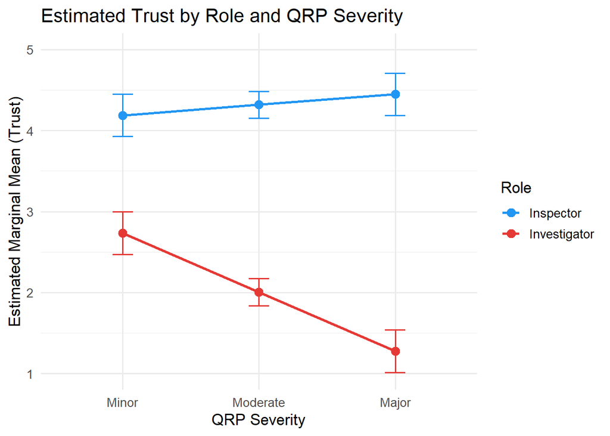

```r
emm_trust_df = as.data.frame(emmeans(T4, ~ role_ec * severity_num,
                                       at = list(severity_num = c(-1, 0, 1))))
emm_trust_df = emm_trust_df %>%
  mutate(
    Role     = if_else(role_ec == 1, "Inspector", "Investigator"),
    Severity = factor(severity_num, levels = c(-1, 0, 1),
                      labels = c("Minor", "Moderate", "Major"))
  )

ggplot(emm_trust_df, aes(x = Severity, y = emmean, color = Role, group = Role)) +
  geom_line(linewidth = 1) +
  geom_point(size = 3) +
  geom_errorbar(aes(ymin = lower.CL, ymax = upper.CL), width = 0.15) +
  scale_color_manual(values = c("Inspector" = "#2196F3", "Investigator" = "#E53935")) +
  labs(title = "Estimated Trust by Role and QRP Severity",
       y = "Estimated Marginal Mean (Trust)", x = "QRP Severity") +
  theme_minimal(base_size = 13) +
  coord_cartesian(ylim = c(1, 5))
```

## STEP 5: RQ2 — Likeability models (H2a: main effect of role; H2b: role × severity)

```r
# Model 1: Role only (H2a)
L1 = lmer(
  likeability ~ role_ec + (1 | responseid) + (1 | severity),
  data = tl_dat, REML = FALSE,
  control = lmerControl(optimizer = "bobyqa")
)

# Model 2: Severity only
L2 = lmer(
  likeability ~ severity_num + (1 | responseid) + (1 | severity),
  data = tl_dat, REML = FALSE,
  control = lmerControl(optimizer = "bobyqa")
)
```

```
## boundary (singular) fit: see help('isSingular')
```

```r
# Model 3: Role + Severity (additive)
L3 = lmer(
  likeability ~ role_ec + severity_num + (1 | responseid) + (1 | severity),
  data = tl_dat, REML = FALSE,
  control = lmerControl(optimizer = "bobyqa")
)
```

```
## boundary (singular) fit: see help('isSingular')
```

```r
# Model 4: Role × Severity interaction (H2b)
L4 = lmer(
  likeability ~ role_ec * severity_num + (1 | responseid) + (1 | severity),
  data = tl_dat, REML = FALSE,
  control = lmerControl(optimizer = "bobyqa")
)
```

```
## boundary (singular) fit: see help('isSingular')
```

```r
# ── Model comparison ───────────────────────────────────────────────────────
anova(L1, L2, L3, L4)
```

```
## Data: tl_dat
## Models:
## L1: likeability ~ role_ec + (1 | responseid) + (1 | severity)
## L2: likeability ~ severity_num + (1 | responseid) + (1 | severity)
## L3: likeability ~ role_ec + severity_num + (1 | responseid) + (1 | severity)
## L4: likeability ~ role_ec * severity_num + (1 | responseid) + (1 | severity)
##    npar    AIC    BIC  logLik -2*log(L)  Chisq Df Pr(>Chisq)
## L1    5 5023.5 5051.2 -2506.7    5013.5
## L2    5 5820.0 5847.7 -2905.0    5810.0   0.00  0
## L3    6 5014.9 5048.2 -2501.4    5002.9 807.11  1  < 2.2e-16 ***
## L4    7 4797.2 4836.1 -2391.6    4783.2 219.64  1  < 2.2e-16 ***
## ---
## Signif. codes:  0 '***' 0.001 '**' 0.01 '*' 0.05 '.' 0.1 ' ' 1
```

```r
summary(L1)
```

```
## Linear mixed model fit by maximum likelihood . t-tests use Satterthwaite's
##   method [lmerModLmerTest]
## Formula: likeability ~ role_ec + (1 | responseid) + (1 | severity)
##    Data: tl_dat
## Control: lmerControl(optimizer = "bobyqa")
##
##       AIC       BIC    logLik -2*log(L)  df.resid
##    5023.5    5051.2   -2506.7    5013.5      1892
##
## Scaled residuals:
##     Min      1Q  Median      3Q     Max
## -3.1909 -0.6990  0.0582  0.6670  2.9110
##
## Random effects:
##  Groups     Name        Variance Std.Dev.
##  responseid (Intercept) 0.01654  0.1286
##  severity   (Intercept) 0.01731  0.1316
##  Residual               0.80362  0.8964
## Number of obs: 1897, groups:  responseid, 317; severity, 3
##
## Fixed effects:
##              Estimate Std. Error        df t value Pr(>|t|)
## (Intercept) 3.147e+00  7.904e-02 3.050e+00   39.82 3.04e-05 ***
## role_ec     6.581e-01  2.058e-02 1.579e+03   31.98  < 2e-16 ***
## ---
## Signif. codes:  0 '***' 0.001 '**' 0.01 '*' 0.05 '.' 0.1 ' ' 1
##
## Correlation of Fixed Effects:
##         (Intr)
## role_ec 0.000
```

```r
summary(L3)
```

```
## Linear mixed model fit by maximum likelihood . t-tests use Satterthwaite's
##   method [lmerModLmerTest]
## Formula: likeability ~ role_ec + severity_num + (1 | responseid) + (1 |
##     severity)
##    Data: tl_dat
## Control: lmerControl(optimizer = "bobyqa")
##
##       AIC       BIC    logLik -2*log(L)  df.resid
##    5014.9    5048.2   -2501.4    5002.9      1891
##
## Scaled residuals:
##     Min      1Q  Median      3Q     Max
## -3.1981 -0.6935  0.0496  0.6826  2.9350
##
## Random effects:
##  Groups     Name        Variance Std.Dev.
##  responseid (Intercept) 0.01624  0.1275
##  severity   (Intercept) 0.00000  0.0000
##  Residual               0.80275  0.8960
## Number of obs: 1897, groups:  responseid, 317; severity, 3
##
## Fixed effects:
##                Estimate Std. Error         df t value Pr(>|t|)
## (Intercept)     3.14737    0.02178  317.29500 144.492  < 2e-16 ***
## role_ec         0.65812    0.02057 1581.20289  31.993  < 2e-16 ***
## severity_num   -0.16606    0.02521 1582.93864  -6.587 6.11e-11 ***
## ---
## Signif. codes:  0 '***' 0.001 '**' 0.01 '*' 0.05 '.' 0.1 ' ' 1
##
## Correlation of Fixed Effects:
##             (Intr) role_c
## role_ec      0.001
## severity_nm -0.002  0.001
## optimizer (bobyqa) convergence code: 0 (OK)
## boundary (singular) fit: see help('isSingular')
```

```r
summary(L4)
```

```
## Linear mixed model fit by maximum likelihood . t-tests use Satterthwaite's
##   method [lmerModLmerTest]
## Formula: likeability ~ role_ec * severity_num + (1 | responseid) + (1 |
##     severity)
##    Data: tl_dat
## Control: lmerControl(optimizer = "bobyqa")
##
##       AIC       BIC    logLik -2*log(L)  df.resid
##    4797.2    4836.1   -2391.6    4783.2      1890
##
## Scaled residuals:
##     Min      1Q  Median      3Q     Max
## -3.5500 -0.6483  0.0194  0.6496  3.5166
##
## Random effects:
##  Groups     Name        Variance Std.Dev.
##  responseid (Intercept) 0.0335   0.1830
##  severity   (Intercept) 0.0000   0.0000
##  Residual               0.6987   0.8359
## Number of obs: 1897, groups:  responseid, 317; severity, 3
##
## Fixed effects:
##                        Estimate Std. Error         df t value Pr(>|t|)
## (Intercept)             3.14753    0.02177  317.44044 144.554  < 2e-16 ***
## role_ec                 0.65755    0.01919 1581.24706  34.262  < 2e-16 ***
## severity_num           -0.16574    0.02352 1582.89229  -7.046 2.73e-12 ***
## role_ec:severity_num    0.36103    0.02352 1581.38391  15.349  < 2e-16 ***
## ---
## Signif. codes:  0 '***' 0.001 '**' 0.01 '*' 0.05 '.' 0.1 ' ' 1
##
## Correlation of Fixed Effects:
##             (Intr) role_c svrty_
## role_ec      0.001
## severity_nm -0.002  0.001
## rl_c:svrty_  0.001 -0.002  0.001
## optimizer (bobyqa) convergence code: 0 (OK)
## boundary (singular) fit: see help('isSingular')
```

Planned contrasts: Bonferroni α = .001

```r
emm_like_role = emmeans(L4, pairwise ~ role_ec | severity_num,
                          at = list(severity_num = c(-1, 0, 1)),
                          adjust = "bonferroni")
```

```
## boundary (singular) fit: see help('isSingular')
```

```r
summary(emm_like_role$contrasts)
```

```
## severity_num = -1:
##  contrast               estimate     SE   df t.ratio p.value
##  (role_ec-1) - role_ec1   -0.593 0.0608 1582  -9.749 <0.0001
##
## severity_num =  0:
##  contrast               estimate     SE   df t.ratio p.value
##  (role_ec-1) - role_ec1   -1.315 0.0384 1583 -34.229 <0.0001
##
## severity_num =  1:
##  contrast               estimate     SE   df t.ratio p.value
##  (role_ec-1) - role_ec1   -2.037 0.0607 1583 -33.553 <0.0001
##
## Degrees-of-freedom method: kenward-roger
```

```r
eff_size(emmeans(L4, ~ role_ec | severity_num,
                  at = list(severity_num = c(-1, 0, 1))),
         sigma = sigma(L4), edf = df.residual(L4))
```

```
## boundary (singular) fit: see help('isSingular')
```

```
## severity_num = -1:
##  contrast               effect.size     SE   df lower.CL upper.CL
##  (role_ec-1) - role_ec1      -0.709 0.0737 4.53   -0.905   -0.514
##
## severity_num =  0:
##  contrast               effect.size     SE   df lower.CL upper.CL
##  (role_ec-1) - role_ec1      -1.573 0.0526 5.26   -1.707   -1.440
##
## severity_num =  1:
##  contrast               effect.size     SE   df lower.CL upper.CL
##  (role_ec-1) - role_ec1      -2.437 0.0827 4.48   -2.657   -2.217
##
## sigma used for effect sizes: 0.8359
## Degrees-of-freedom method: inherited from kenward-roger when re-gridding
## Confidence level used: 0.95
```

Plot Role × Severity for likeability

```r
emm_like_df = as.data.frame(emmeans(L4, ~ role_ec * severity_num,
                                      at = list(severity_num = c(-1, 0, 1)))) %>%
  mutate(
    Role     = if_else(role_ec == 1, "Inspector", "Investigator"),
    Severity = factor(severity_num, levels = c(-1, 0, 1),
                      labels = c("Minor", "Moderate", "Major"))
  )
```

```
## boundary (singular) fit: see help('isSingular')
```

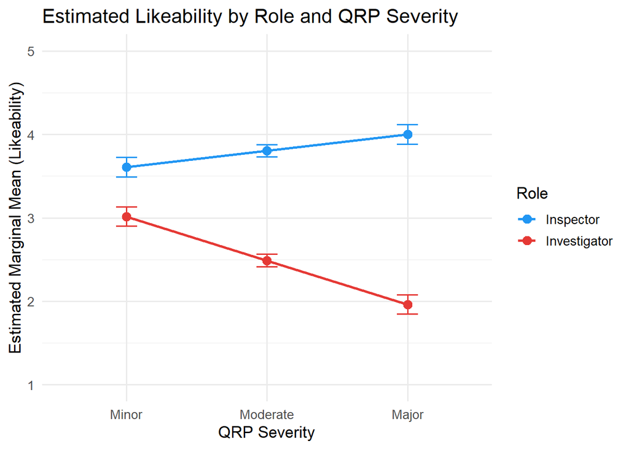

```r
ggplot(emm_like_df, aes(x = Severity, y = emmean, color = Role, group = Role)) +
  geom_line(linewidth = 1) +
  geom_point(size = 3) +
  geom_errorbar(aes(ymin = lower.CL, ymax = upper.CL), width = 0.15) +
  scale_color_manual(values = c("Inspector" = "#2196F3", "Investigator" = "#E53935")) +
  labs(title = "Estimated Likeability by Role and QRP Severity",
       y = "Estimated Marginal Mean (Likeability)", x = "QRP Severity") +
  theme_minimal(base_size = 13) +
  coord_cartesian(ylim = c(1, 5))
```

## STEP 6: RQ3 — Perceived Trueness of the Finding (H3: severity → trueness)

```r
# Trueness is only for investigators, one item per vignette
trueness_dat = filtered_by_age %>%
  transmute(
    responseid,
    minor    = parse_num(kcon),
    moderate = parse_num(hcon),
    major    = parse_num(xcon)
  ) %>%
  pivot_longer(
    cols      = c(minor, moderate, major),
    names_to  = "severity",
    values_to = "trueness"
  ) %>%
  mutate(
    severity     = factor(severity, levels = c("minor", "moderate", "major")),
    severity_num = case_when(
      severity == "minor"    ~ -1,
      severity == "moderate" ~  0,
      severity == "major"    ~  1
    ),
    responseid = factor(responseid),
    trueness_c = trueness - 3
  )

# Descriptives
trueness_dat %>%
  group_by(severity) %>%
  summarise(
    n  = sum(!is.na(trueness)),
    M  = round(mean(trueness, na.rm = TRUE), 2),
    SD = round(sd(trueness,   na.rm = TRUE), 2),
    .groups = "drop"
  ) %>%
  kable(caption = "Trueness Descriptives by QRP Severity") %>%
  kable_styling()
```

Trueness Descriptives by QRP Severity

| severity | n | M | SD |
| --- | --- | --- | --- |
| minor | 315 | 3.00 | 0.92 |
| moderate | 317 | 1.89 | 0.93 |
| major | 317 | 1.53 | 0.88 |

Model FT1: Trueness ~ Severity (H3)

```r
FT1 = lmer(
  trueness_c ~ severity_num + (1 | responseid) + (1 | severity),
  data    = trueness_dat,
  REML    = FALSE,
  control = lmerControl(optimizer = "bobyqa")
)

summary(FT1)
```

```
## Linear mixed model fit by maximum likelihood . t-tests use Satterthwaite's
##   method [lmerModLmerTest]
## Formula: trueness_c ~ severity_num + (1 | responseid) + (1 | severity)
##    Data: trueness_dat
## Control: lmerControl(optimizer = "bobyqa")
##
##       AIC       BIC    logLik -2*log(L)  df.resid
##    2492.4    2516.7   -1241.2    2482.4       944
##
## Scaled residuals:
##     Min      1Q  Median      3Q     Max
## -2.7818 -0.6604 -0.0977  0.4792  4.0222
##
## Random effects:
##  Groups     Name        Variance Std.Dev.
##  responseid (Intercept) 0.1871   0.4325
##  severity   (Intercept) 0.0298   0.1726
##  Residual               0.6447   0.8029
## Number of obs: 949, groups:  responseid, 317; severity, 3
##
## Fixed effects:
##              Estimate Std. Error      df t value Pr(>|t|)
## (Intercept)   -0.8603     0.1058  3.3396  -8.128   0.0026 **
## severity_num  -0.7316     0.1262  2.9981  -5.798   0.0102 *
## ---
## Signif. codes:  0 '***' 0.001 '**' 0.01 '*' 0.05 '.' 0.1 ' ' 1
##
## Correlation of Fixed Effects:
##             (Intr)
## severity_nm 0.000
```

```r
# Planned contrasts across severity levels
emm_trueness = emmeans(FT1, pairwise ~ severity_num,
                         at     = list(severity_num = c(-1, 0, 1)),
                         adjust = "bonferroni")
summary(emm_trueness$contrasts)
```

```
##  contrast                         estimate    SE   df t.ratio p.value
##  (severity_num-1) - severity_num0    0.732 0.217 8.68   3.378  0.0258
##  (severity_num-1) - severity_num1    1.463 0.433 8.68   3.378  0.0258
##  severity_num0 - severity_num1       0.732 0.217 8.68   3.378  0.0258
##
## Degrees-of-freedom method: kenward-roger
## P value adjustment: bonferroni method for 3 tests
```

```r
eff_size(emmeans(FT1, ~ severity_num, at = list(severity_num = c(-1, 0, 1))),
         sigma = sigma(FT1), edf = df.residual(FT1))
```

```
##  contrast                         effect.size    SE   df lower.CL upper.CL
##  (severity_num-1) - severity_num0       0.911 0.271 8.40    0.292     1.53
##  (severity_num-1) - severity_num1       1.822 0.541 8.56    0.589     3.06
##  severity_num0 - severity_num1          0.911 0.271 8.40    0.292     1.53
##
## sigma used for effect sizes: 0.8029
## Degrees-of-freedom method: inherited from kenward-roger when re-gridding
## Confidence level used: 0.95
```

Plot trueness by severity

[figure not shown]

```r
emm_true_df = as.data.frame(
  emmeans(FT1, ~ severity_num, at = list(severity_num = c(-1, 0, 1)))
) %>%
  mutate(Severity = factor(severity_num, levels = c(-1, 0, 1),
                            labels = c("Minor", "Moderate", "Major")))

ggplot(emm_true_df, aes(x = Severity, y = emmean, group = 1)) +
  geom_line(linewidth = 1, color = "#7B1FA2") +
  geom_point(size = 3, color = "#7B1FA2") +
  geom_errorbar(aes(ymin = lower.CL, ymax = upper.CL), width = 0.15,
                color = "#7B1FA2") +
  labs(title = "Perceived Trueness of Finding by QRP Severity",
       y = "Estimated Marginal Mean (Trueness)", x = "QRP Severity") +
  theme_minimal(base_size = 13) +
  coord_cartesian(ylim = c(1, 5))
```

## STEP 7: Robustness checks — demographic covariates

```r
# Attach demographics to tl_dat
demo_dat = filtered_by_age %>%
  transmute(
    responseid = responseid,
    gender     = factor(`gender.identity`),
    political  = factor(political, levels = c(
      "Strongly Liberal", "Liberal", "Lean Liberal",
      "Centrist",
      "Lean Conservative", "Conservative", "Strongly Conservative"
    )),
    religion   = factor(religion)
  )

tl_robust = tl_dat %>%
  mutate(responseid = as.character(responseid)) %>%
  left_join(demo_dat, by = "responseid") %>%
  mutate(responseid = factor(responseid))


# Trust robustness model (Model 4 + demographics)
T4_robust = lmer(
  trust ~ role_ec * severity_num + gender + political + religion +
    (1 | responseid) + (1 | severity),
  data    = tl_robust,
  REML    = FALSE,
  control = lmerControl(optimizer = "bobyqa")
)

L4_robust = lmer(
  likeability ~ role_ec * severity_num + gender + political + religion +
    (1 | responseid) + (1 | severity),
  data    = tl_robust,
  REML    = FALSE,
  control = lmerControl(optimizer = "bobyqa")
)
```

```
## boundary (singular) fit: see help('isSingular')
```

```r
summary(L4_robust)
```

```
## Linear mixed model fit by maximum likelihood . t-tests use Satterthwaite's
##   method [lmerModLmerTest]
## Formula:
## likeability ~ role_ec * severity_num + gender + political + religion +
##     (1 | responseid) + (1 | severity)
##    Data: tl_robust
## Control: lmerControl(optimizer = "bobyqa")
##
##       AIC       BIC    logLik -2*log(L)  df.resid
##    4684.7    4800.6   -2321.4    4642.7      1821
##
## Scaled residuals:
##     Min      1Q  Median      3Q     Max
## -3.3839 -0.6673  0.0129  0.6773  3.5072
##
## Random effects:
##  Groups     Name        Variance Std.Dev.
##  responseid (Intercept) 0.02666  0.1633
##  severity   (Intercept) 0.00000  0.0000
##  Residual               0.70361  0.8388
## Number of obs: 1842, groups:  responseid, 307; severity, 3
##
## Fixed effects:
##                                     Estimate Std. Error         df t value
## (Intercept)                        3.102e+00  1.364e-01  3.070e+02  22.740
## role_ec                            6.591e-01  1.954e-02  1.535e+03  33.722
## severity_num                      -1.653e-01  2.394e-02  1.535e+03  -6.906
## genderNon-binary / third gender    8.698e-02  3.911e-01  3.070e+02   0.222
## genderPrefer not to say            6.434e-01  3.938e-01  3.070e+02   1.634
## genderWoman                        6.979e-02  5.705e-02  3.070e+02   1.223
## politicalLiberal                   2.295e-02  1.362e-01  3.070e+02   0.169
## politicalLean Liberal             -1.086e-01  1.432e-01  3.070e+02  -0.759
## politicalCentrist                 -1.529e-01  1.298e-01  3.070e+02  -1.178
## politicalLean Conservative        -1.007e-01  1.332e-01  3.070e+02  -0.756
## politicalConservative             -9.056e-02  1.281e-01  3.070e+02  -0.707
## politicalStrongly Conservative    -5.682e-03  1.361e-01  3.070e+02  -0.042
## religionIslam                      5.512e-01  3.871e-01  3.070e+02   1.424
## religionJudaism                    1.935e-01  2.740e-01  3.070e+02   0.706
## religionNot Affiliated            -4.497e-02  8.893e-02  3.070e+02  -0.506
## religionOther                      1.578e-01  9.903e-02  3.070e+02   1.594
```

[output cut: 8 more lines]

```
## genderWoman                          0.222
## politicalLiberal                     0.866
## politicalLean Liberal                0.448
## politicalCentrist                    0.240
## politicalLean Conservative           0.450
## politicalConservative                0.480
## politicalStrongly Conservative       0.967
## religionIslam                        0.155
## religionJudaism                      0.481
## religionNot Affiliated               0.613
## religionOther                        0.112
## religionProtestantism (Christian)    0.107
## role_ec:severity_num               < 2e-16 ***
## ---
## Signif. codes:  0 '***' 0.001 '**' 0.01 '*' 0.05 '.' 0.1 ' ' 1
```

```
##
## Correlation matrix not shown by default, as p = 18 > 12.
## Use print(x, correlation=TRUE)  or
##     vcov(x)        if you need it
```

```
## optimizer (bobyqa) convergence code: 0 (OK)
## boundary (singular) fit: see help('isSingular')
```

```r
# Compare role_ec * severity_num effect with and without demographics
summary(T4_robust)
```

```
## Linear mixed model fit by maximum likelihood . t-tests use Satterthwaite's
##   method [lmerModLmerTest]
## Formula: trust ~ role_ec * severity_num + gender + political + religion +
##     (1 | responseid) + (1 | severity)
##    Data: tl_robust
## Control: lmerControl(optimizer = "bobyqa")
##
##       AIC       BIC    logLik -2*log(L)  df.resid
##    4359.6    4475.5   -2158.8    4317.6      1821
##
## Scaled residuals:
##     Min      1Q  Median      3Q     Max
## -4.3868 -0.5747  0.0382  0.6561  4.6739
##
## Random effects:
##  Groups     Name        Variance Std.Dev.
##  responseid (Intercept) 0.007983 0.08935
##  severity   (Intercept) 0.004330 0.06580
##  Residual               0.600858 0.77515
## Number of obs: 1842, groups:  responseid, 307; severity, 3
##
## Fixed effects:
##                                     Estimate Std. Error         df t value
## (Intercept)                          3.25266    0.12418  140.53347  26.194
## role_ec                              1.15780    0.01806 1532.59314  64.105
## severity_num                        -0.30293    0.05152    2.99965  -5.880
## genderNon-binary / third gender     -0.09440    0.33897  306.34155  -0.278
## genderPrefer not to say              0.48797    0.34136  306.34155   1.429
## genderWoman                         -0.01514    0.04944  306.34155  -0.306
## politicalLiberal                    -0.05784    0.11804  306.34155  -0.490
## politicalLean Liberal               -0.14617    0.12407  306.34155  -1.178
## politicalCentrist                   -0.17319    0.11247  306.34155  -1.540
## politicalLean Conservative          -0.12321    0.11542  306.34155  -1.068
## politicalConservative               -0.12023    0.11101  306.34155  -1.083
## politicalStrongly Conservative      -0.11019    0.11796  306.34155  -0.934
## religionIslam                        0.30942    0.33550  306.34155   0.922
## religionJudaism                      0.04051    0.23750  306.34155   0.171
## religionNot Affiliated               0.01069    0.07708  306.34155   0.139
## religionOther                        0.04368    0.08583  306.34155   0.509
## religionProtestantism (Christian)    0.06209    0.04764  306.34155   1.303
## role_ec:severity_num                 0.43594    0.02212 1532.59314  19.708
##                                   Pr(>|t|)
## (Intercept)                        < 2e-16 ***
## role_ec                            < 2e-16 ***
## severity_num                       0.00982 **
## genderNon-binary / third gender    0.78082
## genderPrefer not to say            0.15388
## genderWoman                        0.75972
## politicalLiberal                   0.62448
## politicalLean Liberal              0.23968
## politicalCentrist                  0.12461
## politicalLean Conservative         0.28657
## politicalConservative              0.27965
## politicalStrongly Conservative     0.35096
## religionIslam                      0.35711
## religionJudaism                    0.86469
## religionNot Affiliated             0.88979
## religionOther                      0.61123
## religionProtestantism (Christian)  0.19348
## role_ec:severity_num               < 2e-16 ***
## ---
## Signif. codes:  0 '***' 0.001 '**' 0.01 '*' 0.05 '.' 0.1 ' ' 1
```

```
##
## Correlation matrix not shown by default, as p = 18 > 12.
## Use print(x, correlation=TRUE)  or
##     vcov(x)        if you need it
```

```r
summary(L4_robust)
```

```
## Linear mixed model fit by maximum likelihood . t-tests use Satterthwaite's
##   method [lmerModLmerTest]
## Formula:
## likeability ~ role_ec * severity_num + gender + political + religion +
##     (1 | responseid) + (1 | severity)
##    Data: tl_robust
## Control: lmerControl(optimizer = "bobyqa")
##
##       AIC       BIC    logLik -2*log(L)  df.resid
##    4684.7    4800.6   -2321.4    4642.7      1821
##
## Scaled residuals:
##     Min      1Q  Median      3Q     Max
## -3.3839 -0.6673  0.0129  0.6773  3.5072
##
## Random effects:
##  Groups     Name        Variance Std.Dev.
##  responseid (Intercept) 0.02666  0.1633
##  severity   (Intercept) 0.00000  0.0000
##  Residual               0.70361  0.8388
## Number of obs: 1842, groups:  responseid, 307; severity, 3
##
## Fixed effects:
##                                     Estimate Std. Error         df t value
## (Intercept)                        3.102e+00  1.364e-01  3.070e+02  22.740
## role_ec                            6.591e-01  1.954e-02  1.535e+03  33.722
## severity_num                      -1.653e-01  2.394e-02  1.535e+03  -6.906
## genderNon-binary / third gender    8.698e-02  3.911e-01  3.070e+02   0.222
## genderPrefer not to say            6.434e-01  3.938e-01  3.070e+02   1.634
## genderWoman                        6.979e-02  5.705e-02  3.070e+02   1.223
## politicalLiberal                   2.295e-02  1.362e-01  3.070e+02   0.169
## politicalLean Liberal             -1.086e-01  1.432e-01  3.070e+02  -0.759
## politicalCentrist                 -1.529e-01  1.298e-01  3.070e+02  -1.178
## politicalLean Conservative        -1.007e-01  1.332e-01  3.070e+02  -0.756
## politicalConservative             -9.056e-02  1.281e-01  3.070e+02  -0.707
## politicalStrongly Conservative    -5.682e-03  1.361e-01  3.070e+02  -0.042
## religionIslam                      5.512e-01  3.871e-01  3.070e+02   1.424
## religionJudaism                    1.935e-01  2.740e-01  3.070e+02   0.706
## religionNot Affiliated            -4.497e-02  8.893e-02  3.070e+02  -0.506
## religionOther                      1.578e-01  9.903e-02  3.070e+02   1.594
```

[output cut: 8 more lines]

```
## genderWoman                          0.222
## politicalLiberal                     0.866
## politicalLean Liberal                0.448
## politicalCentrist                    0.240
## politicalLean Conservative           0.450
## politicalConservative                0.480
## politicalStrongly Conservative       0.967
## religionIslam                        0.155
## religionJudaism                      0.481
## religionNot Affiliated               0.613
## religionOther                        0.112
## religionProtestantism (Christian)    0.107
## role_ec:severity_num               < 2e-16 ***
## ---
## Signif. codes:  0 '***' 0.001 '**' 0.01 '*' 0.05 '.' 0.1 ' ' 1
```

```
##
## Correlation matrix not shown by default, as p = 18 > 12.
## Use print(x, correlation=TRUE)  or
##     vcov(x)        if you need it
```

```
## optimizer (bobyqa) convergence code: 0 (OK)
## boundary (singular) fit: see help('isSingular')
```

```r
# Check if the interaction term stays significant in both
fixef(T4)[["role_ec:severity_num"]]
```

```
## [1] 0.4292065
```

```r
fixef(T4_robust)[["role_ec:severity_num"]]
```

```
## [1] 0.4359392
```

```r
fixef(L4)[["role_ec:severity_num"]]
```

```
## [1] 0.3610272
```

```r
fixef(L4_robust)[["role_ec:severity_num"]]
```

```
## [1] 0.3640065
```